# PHÂN TÍCH VÀ DỰ ĐOÁN KHÁCH HÀNG RỜI BỎ DỊCH VỤ

Customer Churn · Phân tích dữ liệu · Hồi quy Logistic

Nguyễn Tấn Phát

**Người thực hiện:** Nguyễn Tấn Phát

**Học phần:** Xử lý số liệu thống kê (2026)

**Đề tài:** Phân tích churn bằng Bootstrap, Permutation Test và Logistic Regression.

**Dữ liệu:** Iranian Churn (UCI, 2020), [DOI: 10.24432/C5JW3Z](https://doi.org/10.24432/C5JW3Z).

# Tóm tắt điều hành (Executive Summary)

**Sau loại trùng:** 2,850 hồ sơ; **446 churn** (15.65%).

- **Khiếu nại:** churn 82.61%, so với 9.77% ở nhóm không khiếu nại (chênh 72,84 điểm phần trăm).
- **Giá trị và tần suất sử dụng:** trung vị `customer_value` thấp hơn 168,97; tần suất sử dụng trung bình thấp hơn 47,17 lượt ở nhóm churn.
- **Dự báo:** Expanded có AP OOF cao nhất (0,770); trên test đạt AP 0,752 và ROC-AUC 0,927.
- **Liên hệ 20% khách điểm cao nhất:** với Reduced, tìm thấy 54/90 churn trên test; Lift 2,98 lần.

*Chưa xác minh được thời điểm cập nhật `status`, nên không xem Expanded là mô hình sẵn sàng triển khai.*

# 1 Bối cảnh và mục tiêu

## 1.1 Bài toán và phạm vi

Bài phân tích tìm các đặc điểm gắn với **churn** và dùng Logistic Regression để xếp hạng khách hàng theo nguy cơ rời bỏ dịch vụ.

Theo [UCI](https://archive.ics.uci.edu/dataset/563/iranian+churn+dataset), các biến đầu vào thuộc **9 tháng đầu**, còn churn được xác định ở cuối **tháng 12**. Chưa rõ `status` được cập nhật khi nào, nên cần thận trọng với mô hình sử dụng biến này.

## 1.2 Câu hỏi phân tích

- **Khách hàng nào dễ churn hơn?** Xét khiếu nại, gói cước, `customer_value` và `frequency_of_use`.
- **Dự báo tốt đến đâu?** So sánh ba mô hình Logistic trên train và test.
- **Liên hệ ai trước?** Nếu chỉ tiếp cận 10–30% khách hàng, ta tìm được bao nhiêu trường hợp churn?

## 1.3 Quy trình phân tích

Sau EDA, ta dùng **Bootstrap** và **Permutation Test** cho bốn so sánh, rồi kiểm tra kết quả trước và sau loại trùng. Dữ liệu được chia **80% train – 20% test**; mô hình và ngưỡng được chọn bằng **5-fold CV trên train**. Test chỉ dùng để đánh giá cuối.

# 2 Dữ liệu và tiền xử lý

## 2.1 Nguồn và dữ liệu đầu vào

```r
data_candidates <- c(
  file.path("data", "Customer Churn.csv"),
  file.path("..", "data", "Customer Churn.csv"),
  "Customer Churn.csv"
)
data_available <- data_candidates[file.exists(data_candidates)]
if (length(data_available) == 0) {
  stop("Không tìm thấy Customer Churn.csv. Hãy đặt CSV vào thư mục data/ ",
       "ở thư mục đang Knit hoặc thư mục cha.")
}
data_path <- data_available[1]
raw_data <- readr::read_csv(
  data_path,
  show_col_types = FALSE
)

data <- raw_data |>
  janitor::clean_names()

cat("<p><strong>Kích thước dữ liệu gốc:</strong> ", nrow(raw_data),
    " dòng × ", ncol(raw_data), " cột.</p>\n", sep = "")
```

**Kích thước dữ liệu gốc:** 3150 dòng × 14 cột.

```r
preview <- knitr::kable(utils::head(raw_data, 6), format = "html",
  row.names = FALSE, digits = 2,
  table.attr = 'class="table table-striped pca-table data-preview-table"')
cat('<div class="data-preview-scroll">', as.character(preview), '</div>\n', sep = "\n")
```

| Call Failure | Complains | Subscription Length | Charge Amount | Seconds of Use | Frequency of use | Frequency of SMS | Distinct Called Numbers | Age Group | Tariff Plan | Status | Age | Customer Value | Churn |
| --- | --- | --- | --- | --- | --- | --- | --- | --- | --- | --- | --- | --- | --- |
| 8 | 0 | 38 | 0 | 4370 | 71 | 5 | 17 | 3 | 1 | 1 | 30 | 197.64 | 0 |
| 0 | 0 | 39 | 0 | 318 | 5 | 7 | 4 | 2 | 1 | 2 | 25 | 46.03 | 0 |
| 10 | 0 | 37 | 0 | 2453 | 60 | 359 | 24 | 3 | 1 | 1 | 30 | 1536.52 | 0 |
| 10 | 0 | 38 | 0 | 4198 | 66 | 1 | 35 | 1 | 1 | 1 | 15 | 240.02 | 0 |
| 3 | 0 | 38 | 0 | 2393 | 58 | 2 | 33 | 1 | 1 | 1 | 15 | 145.80 | 0 |
| 11 | 0 | 38 | 1 | 3775 | 82 | 32 | 28 | 3 | 1 | 1 | 30 | 282.28 | 0 |

[Iranian Churn — UCI](https://archive.ics.uci.edu/dataset/563/iranian+churn+dataset) (2020, CC BY 4.0) gồm **13 biến giải thích và biến đích `churn`**.

## 2.2 Từ điển biến

Các biến và cách mã hóa trong CSV:

```r
variable_dictionary <- tibble::tibble(
  Variable = c(
    "call_failure", "complains", "subscription_length", "charge_amount",
    "seconds_of_use", "frequency_of_use", "frequency_of_sms",
    "distinct_called_numbers", "age_group", "tariff_plan", "status",
    "age", "customer_value", "churn"
  ),
  `Statistical type` = c(
    "Định lượng rời rạc", "Định tính nhị phân", "Định lượng rời rạc",
    "Thứ bậc", "Định lượng rời rạc", "Định lượng rời rạc",
    "Định lượng rời rạc", "Định lượng rời rạc", "Thứ bậc",
    "Định tính nhị phân", "Định tính nhị phân", "Định lượng rời rạc",
    "Định lượng liên tục", "Định tính nhị phân (biến đích)"
  ),
  `Meaning / Coding` = c(
    "Số lần cuộc gọi thất bại.",
    "Có khiếu nại: 0 = Không; 1 = Có.",
    "Thời gian đã đăng ký dịch vụ, tính bằng tháng.",
    "Mức tiền cước được mã hóa theo thứ tự tăng dần; không phải số tiền thực.",
    "Tổng số giây gọi điện.",
    "Tổng số lần gọi.",
    "Tổng số tin nhắn SMS.",
    "Số điện thoại khác nhau mà khách hàng đã gọi.",
    "Nhóm tuổi theo thứ tự 1 (trẻ hơn) đến 5 (lớn tuổi hơn).",
    "Loại gói cước: 1 = Trả theo sử dụng; 2 = Hợp đồng.",
    "Trạng thái thuê bao: 1 = Đang hoạt động; 2 = Không hoạt động.",
    "Tuổi khách hàng, tính bằng năm.",
    "Giá trị khách hàng đã được tính sẵn trong bộ dữ liệu; nguồn không nêu đơn vị.",
    "Trạng thái rời bỏ: 0 = Không churn; 1 = Churn."
  )
)

knitr::kable(
  variable_dictionary,
  caption = "Variable Dictionary — Iranian Churn",
  escape = TRUE,
  table.attr = 'class="table table-striped pca-table dictionary-table"'
) |>
  kableExtra::kable_styling(
    bootstrap_options = c("striped", "hover"),
    full_width = FALSE,
    font_size = 12
  ) |>
  kableExtra::column_spec(3, width = "34em")
```

Variable Dictionary — Iranian Churn

| Variable | Statistical type | Meaning / Coding |
| --- | --- | --- |
| call_failure | Định lượng rời rạc | Số lần cuộc gọi thất bại. |
| complains | Định tính nhị phân | Có khiếu nại: 0 = Không; 1 = Có. |
| subscription_length | Định lượng rời rạc | Thời gian đã đăng ký dịch vụ, tính bằng tháng. |
| charge_amount | Thứ bậc | Mức tiền cước được mã hóa theo thứ tự tăng dần; không phải số tiền thực. |
| seconds_of_use | Định lượng rời rạc | Tổng số giây gọi điện. |
| frequency_of_use | Định lượng rời rạc | Tổng số lần gọi. |
| frequency_of_sms | Định lượng rời rạc | Tổng số tin nhắn SMS. |
| distinct_called_numbers | Định lượng rời rạc | Số điện thoại khác nhau mà khách hàng đã gọi. |
| age_group | Thứ bậc | Nhóm tuổi theo thứ tự 1 (trẻ hơn) đến 5 (lớn tuổi hơn). |
| tariff_plan | Định tính nhị phân | Loại gói cước: 1 = Trả theo sử dụng; 2 = Hợp đồng. |
| status | Định tính nhị phân | Trạng thái thuê bao: 1 = Đang hoạt động; 2 = Không hoạt động. |
| age | Định lượng rời rạc | Tuổi khách hàng, tính bằng năm. |
| customer_value | Định lượng liên tục | Giá trị khách hàng đã được tính sẵn trong bộ dữ liệu; nguồn không nêu đơn vị. |
| churn | Định tính nhị phân (biến đích) | Trạng thái rời bỏ: 0 = Không churn; 1 = Churn. |

`charge_amount` có **7 hồ sơ mang mã 10** sau loại trùng, trong khi UCI ghi thang 0–9. Vì vậy, ta chỉ xem biến này là **mức cước có thứ tự**, không coi là số tiền.

## 2.3 Chất lượng dữ liệu

```r
quality_report <- tibble(
  Metric = c("Number of Observations", "Number of Variables", "Total Data Cells",
    "Missing Cells", "Missing Cell Rate", "Fully Duplicated Rows",
    "Churned Customers", "Churn Rate"),
  Value = c(nrow(data), ncol(data), nrow(data) * ncol(data),
    sum(is.na(data)), scales::percent(mean(is.na(data)), accuracy = 0.01),
    sum(duplicated(data)), sum(data$churn == 1, na.rm = TRUE),
    scales::percent(mean(data$churn == 1, na.rm = TRUE), accuracy = 0.01))
)
compact_table_with_note(quality_report, "Data Quality Summary", paste0(
  "<strong>Nhận xét</strong><ul>",
  "<li>Dữ liệu gốc có <b>", scales::comma(nrow(data)), " hồ sơ</b> và <b>", ncol(data), " biến</b>; có <b>", sum(is.na(data)), " ô thiếu.</b></li>",
  "<li>Có <b>", sum(duplicated(data)), " dòng trùng hoàn toàn</b>, sẽ loại trước khi chia train/test.</li>",
  "<li>Ghi nhận <b>", sum(data$churn == 1), " hồ sơ churn</b> (",
  scales::percent(mean(data$churn == 1), accuracy = 0.01), ").</li>",
  "</ul>"))
```

Data Quality Summary

| Metric | Value |
| --- | --- |
| Number of Observations | 3150 |
| Number of Variables | 14 |
| Total Data Cells | 44100 |
| Missing Cells | 0 |
| Missing Cell Rate | 0.00% |
| Fully Duplicated Rows | 300 |
| Churned Customers | 495 |
| Churn Rate | 15.71% |

**Nhận xét**

- Dữ liệu gốc có **3,150 hồ sơ** và **14 biến**; có **0 ô thiếu.**
- Có **300 dòng trùng hoàn toàn**, sẽ loại trước khi chia train/test.
- Ghi nhận **495 hồ sơ churn** (15.71%).

Bảng trên là **dữ liệu gốc**, trước khi loại trùng.

```r
missing_profile <- tibble::tibble(
  Variable = names(raw_data),
  Missing = vapply(raw_data, function(x) sum(is.na(x)), integer(1)),
  `Missing rate` = vapply(raw_data, function(x) mean(is.na(x)), numeric(1))
)
missing_profile <- dplyr::mutate(missing_profile,
  `Missing rate` = scales::percent(`Missing rate`, accuracy = .01))
if (any(missing_profile$Missing > 0L)) {
  cat(as.character(tab(dplyr::filter(missing_profile, Missing > 0L),
                            "Biến có giá trị thiếu")))
} else {
  cat("<p><strong>Kết quả:</strong> Cả ", ncol(raw_data),
      " biến đều có <strong>0 giá trị thiếu</strong> trong file gốc.</p>")
}
```

**Kết quả:** Cả 14 biến đều có **0 giá trị thiếu** trong file gốc.

```r
cat('<details class="pca-details"><summary>Xem mức thiếu theo từng biến</summary>')
```

**Xem mức thiếu theo từng biến**

```r
cat(as.character(tab(missing_profile, "Missingness by Variable", digits = 0)))
```

Missingness by Variable

| Variable | Missing | Missing rate |
| --- | --- | --- |
| Call Failure | 0 | 0.00% |
| Complains | 0 | 0.00% |
| Subscription Length | 0 | 0.00% |
| Charge Amount | 0 | 0.00% |
| Seconds of Use | 0 | 0.00% |
| Frequency of use | 0 | 0.00% |
| Frequency of SMS | 0 | 0.00% |
| Distinct Called Numbers | 0 | 0.00% |
| Age Group | 0 | 0.00% |
| Tariff Plan | 0 | 0.00% |
| Status | 0 | 0.00% |
| Age | 0 | 0.00% |
| Customer Value | 0 | 0.00% |
| Churn | 0 | 0.00% |

```r
cat('</details>')
```

## 2.4 Hồ sơ trùng và mức độ thiếu dữ liệu

```r
duplicate_groups <- data |>
  count(across(everything()), name = "Frequency") |>
  filter(Frequency > 1) |>
  arrange(desc(Frequency))

n_before_dedup <- nrow(data)
duplicate_count <- sum(duplicated(data))
churn_rate_before_dedup <- mean(data$churn == "Churn")
data_before_dedup <- data # Giữ toàn bộ 3.150 dòng để kiểm tra độ nhạy.

data <- data |>
  distinct()

n_after_dedup <- nrow(data)

duplicate_summary <- tibble(
  Metric = c(
    "Observations before deduplication",
    "Duplicate groups",
    "Repeated rows removed",
    "Observations after deduplication"
  ),
  Value = c(
    n_before_dedup,
    nrow(duplicate_groups),
    duplicate_count,
    n_after_dedup
  )
)

compact_table_with_note(duplicate_summary, "Duplicate Removal Summary", paste0(
  "<strong>Nhận xét</strong><ul>",
  "<li>Loại <b>", duplicate_count, " dòng trùng toàn bộ 14 trường</b>; còn <b>",
  scales::comma(n_after_dedup), " hồ sơ</b>.</li>",
  "<li>Tỷ lệ churn thay đổi từ <b>",
  scales::percent(churn_rate_before_dedup, accuracy = 0.01), "</b> lên <b>",
  scales::percent(mean(data$churn == "Churn"), accuracy = 0.01),
  "</b> (", num(100 * (mean(data$churn == "Churn") - churn_rate_before_dedup), 2), " điểm phần trăm).</li>",
  "</ul>"))
```

Duplicate Removal Summary

| Metric | Value |
| --- | --- |
| Observations before deduplication | 3150 |
| Duplicate groups | 165 |
| Repeated rows removed | 300 |
| Observations after deduplication | 2850 |

**Nhận xét**

Các dòng trùng **cả 14 trường** được giữ lại một bản. Dữ liệu không có mã khách hàng nên chưa biết các dòng giống nhau có thực sự thuộc cùng người hay không.

## 2.5 Giá trị bất thường

```r
continuous_vars <- c(
  "call_failure",
  "subscription_length",
  "seconds_of_use",
  "frequency_of_use",
  "frequency_of_sms",
  "distinct_called_numbers",
  "customer_value"
)

iqr_outlier_summary <- map_dfr(
  continuous_vars,
  function(var_name) {
    x <- data[[var_name]]
    q1 <- quantile(x, 0.25, na.rm = TRUE)
    q3 <- quantile(x, 0.75, na.rm = TRUE)
    iqr_value <- IQR(x, na.rm = TRUE)
    lower <- q1 - 1.5 * iqr_value
    upper <- q3 + 1.5 * iqr_value

    tibble(
      Variable = var_name,
      Q1 = q1,
      Q3 = q3,
      IQR = iqr_value,
      Lower_bound = lower,
      Upper_bound = upper,
      Outlier_count = sum(x < lower | x > upper, na.rm = TRUE),
      Outlier_rate = mean(x < lower | x > upper, na.rm = TRUE)
    )
  }
)

knitr::kable(
  iqr_outlier_summary,
  digits = 3,
  caption = "Outlier Detection Using the IQR Rule"
) |>
  kableExtra::kable_styling(
    bootstrap_options = c("striped", "hover"),
    full_width = FALSE
  )
```

Outlier Detection Using the IQR Rule

| Variable | Q1 | Q3 | IQR | Lower_bound | Upper_bound | Outlier_count | Outlier_rate |
| --- | --- | --- | --- | --- | --- | --- | --- |
| call_failure | 1.000 | 12.00 | 11.000 | -15.500 | 28.500 | 44 | 0.015 |
| subscription_length | 29.000 | 38.00 | 9.000 | 15.500 | 51.500 | 208 | 0.073 |
| seconds_of_use | 1458.750 | 6500.00 | 5041.250 | -6103.125 | 14061.875 | 189 | 0.066 |
| frequency_of_use | 28.000 | 96.00 | 68.000 | -74.000 | 198.000 | 118 | 0.041 |
| frequency_of_sms | 7.000 | 88.00 | 81.000 | -114.500 | 209.500 | 333 | 0.117 |
| distinct_called_numbers | 11.000 | 34.00 | 23.000 | -23.500 | 68.500 | 82 | 0.029 |
| customer_value | 117.528 | 790.08 | 672.552 | -891.301 | 1798.909 | 104 | 0.036 |

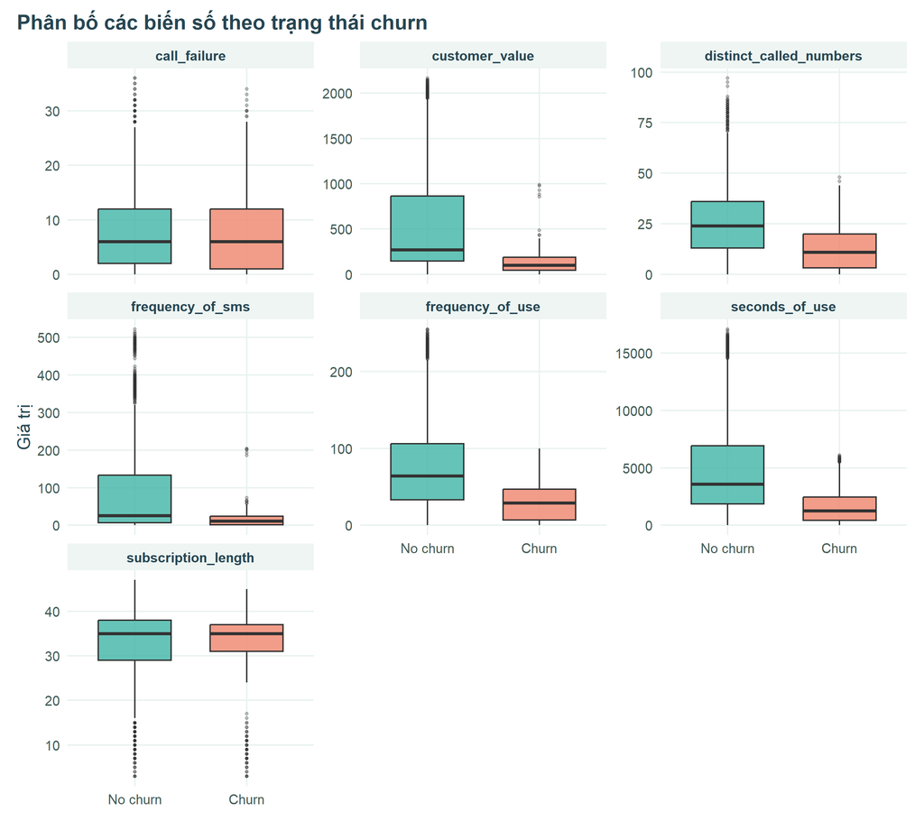

```r
data |>
  dplyr::select(all_of(continuous_vars), churn) |>
  pivot_longer(
    cols = -churn,
    names_to = "Variable",
    values_to = "Value"
  ) |>
  ggplot(aes(x = churn, y = Value, fill = churn)) +
  geom_boxplot(alpha = 0.82, outlier.alpha = 0.28,
               outlier.size = 0.8, width = 0.65) +
  scale_fill_manual(values = churn_colors, drop = FALSE) +
  facet_wrap(~ Variable, scales = "free_y", ncol = 3) +
  labs(
    title = "Phân bố các biến số theo trạng thái churn",
    x = NULL,
    y = "Giá trị"
  ) +
  guides(fill = "none")
```

Biến có tỷ lệ vượt ngưỡng IQR cao nhất là **frequency_of_sms** (**11.7%**). Chưa có dấu hiệu lỗi nhập liệu, nên ta **không xóa các giá trị này**.

# 3 Khám phá churn và bằng chứng thống kê

## 3.1 Tỷ lệ khách hàng rời bỏ

```r
churn_summary <- data |>
  count(churn) |>
  mutate(
    Proportion = n / sum(n)
  )

compact_table_with_note(churn_summary, "Churn Distribution", paste0(
  "<strong>Nhận xét</strong><ul>",
  "<li>Nhóm churn: <b>", sum(data$churn == "Churn"), " / ", nrow(data),
  " khách hàng</b> (", scales::percent(mean(data$churn == "Churn"), accuracy = 0.01), ").</li>",
  "<li>Nếu luôn dự đoán No churn, Accuracy đạt ",
  scales::percent(mean(data$churn == "No churn"), accuracy = 0.1),
  " nhưng Sensitivity bằng 0. Vì vậy cần theo dõi cả tỷ lệ phát hiện churn và cảnh báo sai.</li>",
  "</ul>"))
```

Churn Distribution

| churn | n | Proportion |
| --- | --- | --- |
| No churn | 2404 | 0.844 |
| Churn | 446 | 0.156 |

**Nhận xét**

- Nhóm churn: **446 / 2850 khách hàng** (15.65%).
- Nếu luôn dự đoán No churn, Accuracy đạt 84.4% nhưng Sensitivity bằng 0. Vì vậy cần theo dõi cả tỷ lệ phát hiện churn và cảnh báo sai.

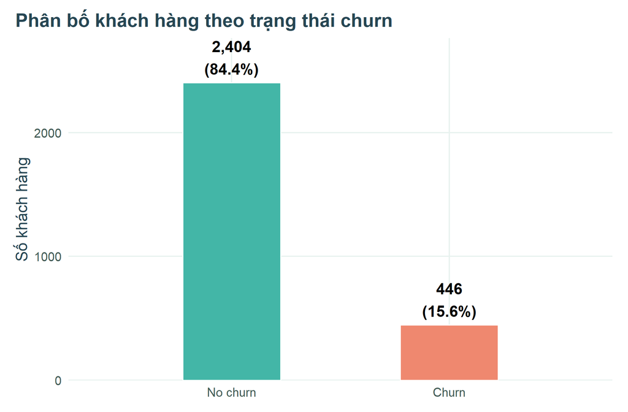

```r
ggplot(churn_summary, aes(x = churn, y = n, fill = churn)) +
  geom_col(width = 0.45, color = "white", linewidth = 0.4) +
  scale_fill_manual(values = churn_colors, drop = FALSE) +
  geom_text(
    aes(
      label = paste0(
        scales::comma(n),
        "\n(",
        scales::percent(Proportion, accuracy = 0.1),
        ")"
      )
    ),
    vjust = -0.25,
    fontface = "bold"
  ) +
  scale_y_continuous(expand = expansion(mult = c(0, 0.15))) +
  scale_x_discrete(expand = expansion(add = 0.75)) +
  labs(
    title = "Phân bố khách hàng theo trạng thái churn",
    x = NULL,
    y = "Số khách hàng"
  ) +
  guides(fill = "none")
```

## 3.2 Đặc điểm sử dụng dịch vụ

```r
descriptive_table <- data |>
  dplyr::select(all_of(continuous_vars)) |>
  summarise(
    across(
      everything(),
      list(
        N = ~ sum(!is.na(.x)),
        Mean = ~ mean(.x, na.rm = TRUE),
        SD = ~ sd(.x, na.rm = TRUE),
        Min = ~ min(.x, na.rm = TRUE),
        Q1 = ~ quantile(.x, 0.25, na.rm = TRUE),
        Median = ~ median(.x, na.rm = TRUE),
        Q3 = ~ quantile(.x, 0.75, na.rm = TRUE),
        Max = ~ max(.x, na.rm = TRUE)
      ),
      .names = "{.col}_{.fn}"
    )
  ) |>
  pivot_longer(
    everything(),
    names_to = c("Variable", ".value"),
    names_pattern = "(.+)_(N|Mean|SD|Min|Q1|Median|Q3|Max)$"
  )

knitr::kable(
  descriptive_table,
  digits = 2,
  caption = "Descriptive Statistics of Numeric Variables",
  table.attr = 'class="table table-striped pca-table descriptive-table"'
) |>
  kableExtra::kable_styling(
    bootstrap_options = c("striped", "hover"),
    full_width = FALSE
  ) |>
  kableExtra::column_spec(1, bold = TRUE) |>
  kableExtra::column_spec(7, bold = TRUE)
```

Descriptive Statistics of Numeric Variables

| Variable | N | Mean | SD | Min | Q1 | Median | Q3 | Max |
| --- | --- | --- | --- | --- | --- | --- | --- | --- |
| call_failure | 2850 | 7.80 | 7.33 | 0 | 1.00 | 6.00 | 12.00 | 36.00 |
| subscription_length | 2850 | 32.45 | 8.72 | 3 | 29.00 | 35.00 | 38.00 | 47.00 |
| seconds_of_use | 2850 | 4534.24 | 4199.71 | 0 | 1458.75 | 3041.00 | 6500.00 | 17090.00 |
| frequency_of_use | 2850 | 70.48 | 57.40 | 0 | 28.00 | 54.50 | 96.00 | 255.00 |
| frequency_of_sms | 2850 | 73.79 | 112.06 | 0 | 7.00 | 22.00 | 88.00 | 522.00 |
| distinct_called_numbers | 2850 | 23.87 | 17.19 | 0 | 11.00 | 21.00 | 34.00 | 97.00 |
| customer_value | 2850 | 474.99 | 514.44 | 0 | 117.53 | 232.52 | 790.08 | 2165.28 |

- **Thời lượng gọi trung vị:** churn **1.256 giây**, không churn **3.596 giây**.
- **Customer Value trung vị:** churn **102,56**, không churn **271,54**.
- **Thời lượng gọi lệch phải:** trung vị **3.041 giây**, tối đa **17.090 giây**; trung vị phản ánh mức sử dụng điển hình tốt hơn.

## 3.3 Churn theo nhóm khách hàng

```r
categorical_vars <- c("complains", "tariff_plan", "status", "age_group")
category_names <- c("Khiếu nại", "Gói cước", "Trạng thái thuê bao", "Nhóm tuổi")

# Mỗi mức của biến phân loại chỉ chiếm một dòng: tổng, số churn và tỷ lệ churn.
categorical_churn_summary <- purrr::map_dfr(categorical_vars, function(v) {
  data |>
    dplyr::count(Level = as.character(.data[[v]]),
                 Churn = as.character(churn), name = "Count") |>
    tidyr::pivot_wider(names_from = Churn, values_from = Count, values_fill = 0L) |>
    dplyr::mutate(
      Variable = v,
      Customers = `No churn` + Churn,
      `Churn rate` = Churn / Customers,
      .before = 1
    ) |>
    dplyr::select(Variable, Level, Customers, `No churn`, Churn, `Churn rate`)
})

row_groups <- stats::setNames(
  vapply(categorical_vars,
         function(v) sum(categorical_churn_summary$Variable == v), integer(1)),
  category_names
)
category_table <- categorical_churn_summary |>
  dplyr::mutate(`Churn rate` = scales::percent(`Churn rate`, accuracy = 0.1)) |>
  dplyr::select(-Variable)

knitr::kable(
  category_table, format = "html", row.names = FALSE,
  col.names = c("Nhóm khách hàng", "Tổng KH", "No churn", "Churn", "Churn rate"),
  caption = "Churn Distribution by Customer Group",
  table.attr = 'class="table table-striped pca-table categorical-summary-table"'
) |>
  kableExtra::kable_styling(
    bootstrap_options = c("striped", "hover"), full_width = FALSE
  ) |>
  kableExtra::pack_rows(
    index = row_groups,
    label_row_css = "background-color:#dfeee9; color:#245d56; font-weight:700;"
  ) |>
  kableExtra::column_spec(5, bold = TRUE)
```

Churn Distribution by Customer Group

| Nhóm khách hàng | Tổng KH | No churn | Churn | Churn rate |
| --- | --- | --- | --- | --- |
| **Khiếu nại** |  |  |  |  |
| Complaint | 230 | 40 | 190 | 82.6% |
| No complaint | 2620 | 2364 | 256 | 9.8% |
| **Gói cước** |  |  |  |  |
| Plan 1 | 2621 | 2181 | 440 | 16.8% |
| Plan 2 | 229 | 223 | 6 | 2.6% |
| **Trạng thái thuê bao** |  |  |  |  |
| Status 1 | 2166 | 2045 | 121 | 5.6% |
| Status 2 | 684 | 359 | 325 | 47.5% |
| **Nhóm tuổi** |  |  |  |  |
| Age group 1 | 112 | 112 | 0 | 0.0% |
| Age group 2 | 921 | 764 | 157 | 17.0% |
| Age group 3 | 1296 | 1083 | 213 | 16.4% |
| Age group 4 | 367 | 293 | 74 | 20.2% |
| Age group 5 | 154 | 152 | 2 | 1.3% |

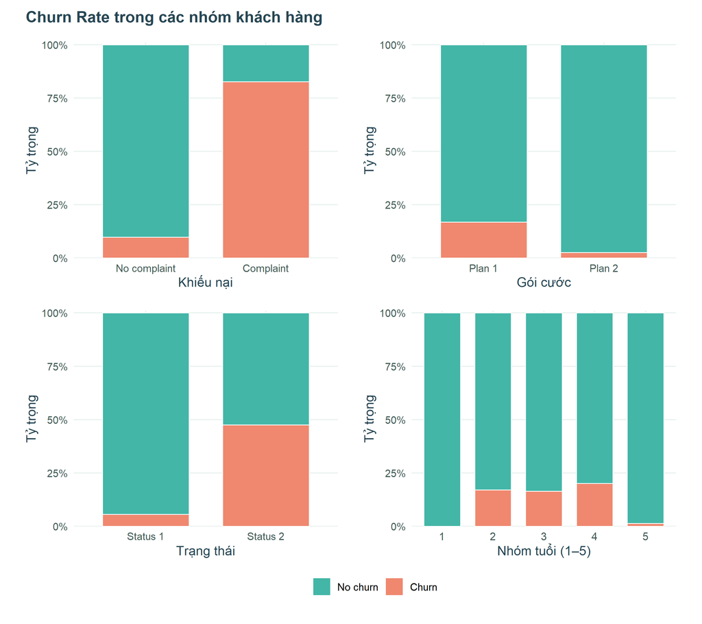

```r
plot_categorical_churn <- function(var_name, x_label) {
  plot_data <- data |>
    count(.data[[var_name]], churn) |>
    group_by(.data[[var_name]]) |>
    mutate(Proportion = n / sum(n)) |>
    ungroup()

  ggplot(
    plot_data,
    aes(
      x = .data[[var_name]],
      y = Proportion,
      fill = churn
    )
  ) +
    geom_col(position = "stack", width = 0.72,
             color = "white", linewidth = 0.35) +
    scale_fill_manual(values = churn_colors, drop = FALSE) +
    scale_y_continuous(labels = scales::percent, limits = c(0, 1),
                       expand = expansion(mult = c(0, 0.01))) +
    labs(
      x = x_label,
      y = "Tỷ trọng",
      fill = "Churn"
    )
}

p1 <- plot_categorical_churn("complains", "Khiếu nại")
p2 <- plot_categorical_churn("tariff_plan", "Gói cước")
p3 <- plot_categorical_churn("status", "Trạng thái")
p4 <- plot_categorical_churn("age_group", "Nhóm tuổi (1–5)") +
  scale_x_discrete(labels = function(x) sub("Age group ", "", x, fixed = TRUE)) +
  theme(axis.text.x = element_text(size = 10, margin = margin(t = 6)))

((p1 + p2) / (p3 + p4)) +
  patchwork::plot_layout(guides = "collect") +
  patchwork::plot_annotation(title = "Churn Rate trong các nhóm khách hàng") &
  theme(legend.position = "bottom")
```

**Chênh lệch đáng chú ý:**

- **Khiếu nại:** churn **82.61%** trong nhóm có khiếu nại (230 người), so với **9.77%** ở nhóm còn lại.
- **Gói cước:** `Plan 1` churn **16.79%** (2621 khách); `Plan 2` **2.62%** (229 khách).
- **Trạng thái:** `Status 2` churn **47.51%**, so với **5.59%** ở `Status 1`.

Đây là **khác biệt quan sát**, chưa cho biết nguyên nhân. Riêng `status` chưa rõ thời điểm ghi nhận.

## 3.4 Tương quan giữa các biến

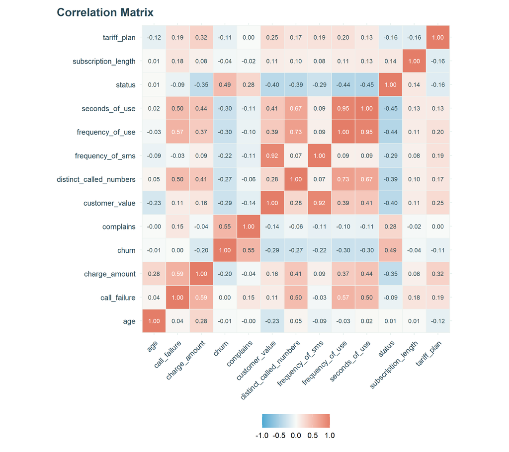

```r
# Mã hóa 4 biến nhị phân thành 0/1 để tính tương quan Pearson.
# Dữ liệu phân loại gốc vẫn được giữ trong đối tượng data.
cor_data <- data |>
  dplyr::transmute(
    call_failure,
    subscription_length,
    charge_amount,
    seconds_of_use,
    frequency_of_use,
    frequency_of_sms,
    distinct_called_numbers,
    age,
    customer_value,
    complains = as.integer(complains == "Complaint"),
    tariff_plan = as.integer(tariff_plan == "Plan 2"),
    status = as.integer(status == "Status 2"),
    churn = as.integer(churn == "Churn")
  )

# Kiểm tra tất cả các cột đưa vào cor() đều là numeric.
stopifnot(all(vapply(cor_data, is.numeric, logical(1))))

cor_matrix <- stats::cor(
  cor_data,
  use = "pairwise.complete.obs",
  method = "pearson"
)

cor_long <- as.data.frame(cor_matrix) |>
  rownames_to_column("Variable_1") |>
  pivot_longer(
    cols = -Variable_1,
    names_to = "Variable_2",
    values_to = "Correlation"
  )

ggplot(
  cor_long,
  aes(
    x = Variable_1,
    y = Variable_2,
    fill = Correlation
  )
) +
  geom_tile(color = "#EDF3F0", linewidth = 0.35) +
  geom_text(
    aes(label = sprintf("%.2f", Correlation),
        colour = abs(Correlation) >= 0.55),
    size = 2.7
  ) +
  scale_color_manual(values = c(`TRUE` = "#FFFFFF", `FALSE` = "#324D53"),
                     guide = "none") +
  scale_fill_gradient2(
    low = chart_colors$blue,
    mid = "#F8FAF8",
    high = chart_colors$coral,
    midpoint = 0,
    limits = c(-1, 1)
  ) +
  coord_equal() +
  labs(
    title = "Correlation Matrix",
    x = NULL,
    y = NULL,
    fill = "r"
  ) +
  theme(
    axis.text.x = element_text(
      angle = 45,
      hjust = 1,
      color = chart_colors$ink
    ),
    axis.text.y = element_text(color = chart_colors$ink)
  )
```

Biểu đồ dùng tương quan Pearson; bốn biến nhị phân (`complains`, `tariff_plan`, `status`, `churn`) được mã hóa 0/1.

**Các cặp tương quan nổi bật:**

- **Trong nhóm hành vi:** `seconds_of_use` – `frequency_of_use` có r = **0,945**; `frequency_of_sms` – `customer_value` có r = **0,923**.
- **Với churn:** `complains` có r = **0,546**; `status` có r = **0,493**; `frequency_of_use` có r = **-0,299**.

Hai cặp biến hành vi tương quan mạnh; **VIF trên train** sẽ cho biết mức đa cộng tuyến.

## 3.5 Chênh lệch churn theo khiếu nại — Bootstrap

**Bootstrap (5.000 lần)** ước lượng chênh lệch tỷ lệ churn giữa nhóm có và không có khiếu nại. Ta lấy mẫu lại trong từng nhóm và dùng **khoảng tin cậy percentile 95%**.

```r
complaint_boot_data <- data |>
  transmute(
    complains,
    churn_binary = if_else(churn == "Churn", 1, 0)
  )

complaint_rate_summary <- complaint_boot_data |>
  group_by(complains) |>
  summarise(
    Sample_Size = n(),
    Churn_Count = sum(churn_binary),
    Churn_Rate = mean(churn_binary),
    .groups = "drop"
  )

complaint_level_no <- "No complaint"
complaint_level_yes <- "Complaint"

complaint_diff <- function(d) {
  mean(d$churn_binary[d$complains == complaint_level_yes]) -
    mean(d$churn_binary[d$complains == complaint_level_no])
}
observed_complaint_difference <- complaint_diff(complaint_boot_data)
bootstrap_complaint_stat <- function(dataset, indices) {
  complaint_diff(dataset[indices, , drop = FALSE])
}

set.seed(analysis_seed)
bootstrap_complaint <- boot::boot(
  data = complaint_boot_data,
  statistic = bootstrap_complaint_stat,
  R = 5000,
  strata = complaint_boot_data$complains
)

bootstrap_complaint_ci <- quantile(
  as.numeric(bootstrap_complaint$t),
  probs = c(0.025, 0.975),
  na.rm = TRUE
)

bootstrap_complaint_results <- tibble(
  Statistic = c("Observed difference", "Bootstrap mean", "95% CI - lower", "95% CI - upper"),
  Value = c(observed_complaint_difference, mean(bootstrap_complaint$t, na.rm = TRUE),
            bootstrap_complaint_ci[1], bootstrap_complaint_ci[2])
)
render_analysis(list(complaint_rate_summary, bootstrap_complaint_results),
  c("Churn Rate by Complaint Status", "Bootstrap Estimate of the Churn Rate Difference"),
  paste0("<b>Chênh lệch:</b> ", num(100 * observed_complaint_difference, 2),
    " điểm phần trăm; <b>CI 95%:</b> [",
    num(100 * bootstrap_complaint_ci[1], 2), "; ",
    num(100 * bootstrap_complaint_ci[2], 2), "] điểm phần trăm."), digits = 4)
```

Churn Rate by Complaint Status

| complains | Sample_Size | Churn_Count | Churn_Rate |
| --- | --- | --- | --- |
| No complaint | 2620 | 256 | 0.0977 |
| Complaint | 230 | 190 | 0.8261 |

Bootstrap Estimate of the Churn Rate Difference

| Statistic | Value |
| --- | --- |
| Observed difference | 0.7284 |
| Bootstrap mean | 0.7285 |
| 95% CI - lower | 0.6785 |
| 95% CI - upper | 0.7769 |

**Chênh lệch:** 72,84 điểm phần trăm; **CI 95%:** [67,85; 77,69] điểm phần trăm.

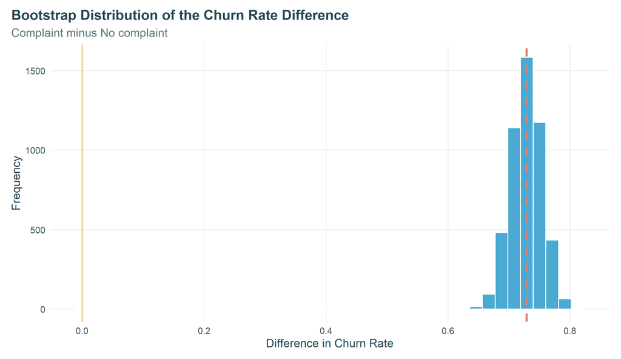

```r
plot_hist_difference <- function(values, observed, title, subtitle, xlab,
                                 permutation = FALSE) {
  df <- tibble::tibble(Difference = as.numeric(values)) |>
    dplyr::filter(is.finite(Difference))
  if (nrow(df) == 0) stop("Không có giá trị hợp lệ để vẽ phân phối")
  bars <- if (dplyr::n_distinct(df$Difference) == 1L) {
    geom_col(data = dplyr::count(df, Difference), aes(y = n),
             width = 0.06, fill = chart_colors$blue)
  } else {
    geom_histogram(bins = 40, fill = chart_colors$blue, colour = "white")
  }
  p <- ggplot(df, aes(Difference)) + bars +
    geom_vline(xintercept = if (permutation) c(-abs(observed), abs(observed)) else observed,
               colour = chart_colors$coral, linetype = "dashed", linewidth = 1.1)
  if (!permutation) p <- p + geom_vline(xintercept = 0, colour = chart_colors$gold)
  p + labs(title = title, subtitle = subtitle, x = xlab, y = "Frequency")
}
plot_hist_difference(bootstrap_complaint$t, observed_complaint_difference,
  "Bootstrap Distribution of the Churn Rate Difference",
  "Complaint minus No complaint", "Difference in Churn Rate")
```

## Giá trị khách hàng theo trạng thái churn — Bootstrap

Ta dùng **5.000 mẫu Bootstrap theo nhóm** để ước lượng chênh lệch **trung vị `customer_value` (Churn − No churn)** và khoảng tin cậy percentile 95%.

```r
bootstrap_difference_median <- function(dataset, group_var, value_var,
                                        group_1, group_0, R = 5000, seed = analysis_seed) {
  d <- dataset |>
    dplyr::transmute(group = as.character({{ group_var }}),
                     value = as.numeric({{ value_var }})) |>
    dplyr::filter(!is.na(group), is.finite(value), group %in% c(group_0, group_1))
  g1 <- d$value[d$group == group_1]
  g0 <- d$value[d$group == group_0]
  if (!length(g1) || !length(g0)) stop("Không đủ dữ liệu cho hai nhóm Bootstrap")
  summary <- d |>
    dplyr::group_by(group) |>
    dplyr::summarise(Sample_Size = dplyr::n(), Mean = mean(value),
                     Median = median(value), Standard_Deviation = sd(value),
                     IQR = IQR(value), .groups = "drop")
  observed <- median(g1) - median(g0)
  set.seed(seed)
  values <- replicate(R, median(sample(g1, length(g1), replace = TRUE)) -
                         median(sample(g0, length(g0), replace = TRUE)))
  if (any(!is.finite(values))) stop("Bootstrap tạo ra giá trị không hợp lệ")
  ci <- unname(quantile(values, c(.025, .975)))
  list(group_summary = summary, observed_difference = observed,
       bootstrap_values = values, confidence_interval = ci,
       result_table = tibble::tibble(
         Statistic = c("Observed median difference", "Bootstrap mean",
                       "Bootstrap standard error", "95% CI - lower", "95% CI - upper"),
         Value = c(observed, mean(values), sd(values), ci)))
}

bootstrap_value <- bootstrap_difference_median(
  data, churn, customer_value, "Churn", "No churn", R = 5000, seed = analysis_seed)
value_medians <- stats::setNames(bootstrap_value$group_summary$Median,
                                bootstrap_value$group_summary$group)
render_analysis(
  list(bootstrap_value$group_summary, bootstrap_value$result_table),
  c("Customer Value by Churn Status", "Bootstrap Median Difference in Customer Value"),
  paste0("<b>Trung vị:</b> churn ", num(value_medians[["Churn"]], 2),
    "; không churn ", num(value_medians[["No churn"]], 2),
    ". <b>Chênh lệch:</b> ", num(bootstrap_value$observed_difference, 2),
    "; <b>CI 95%:</b> [", num(bootstrap_value$confidence_interval[1], 2),
    "; ", num(bootstrap_value$confidence_interval[2], 2), "]."), digits = 3)
```

Customer Value by Churn Status

| group | Sample_Size | Mean | Median | Standard_Deviation | IQR |
| --- | --- | --- | --- | --- | --- |
| Churn | 446 | 132.176 | 102.565 | 130.934 | 142.485 |
| No churn | 2404 | 538.591 | 271.540 | 533.607 | 716.968 |

Bootstrap Median Difference in Customer Value

| Statistic | Value |
| --- | --- |
| Observed median difference | -168.975 |
| Bootstrap mean | -168.298 |
| Bootstrap standard error | 9.814 |
| 95% CI - lower | -187.235 |
| 95% CI - upper | -148.879 |

**Trung vị:** churn 102,56; không churn 271,54. **Chênh lệch:** -168,97; **CI 95%:** [-187,24; -148,88].

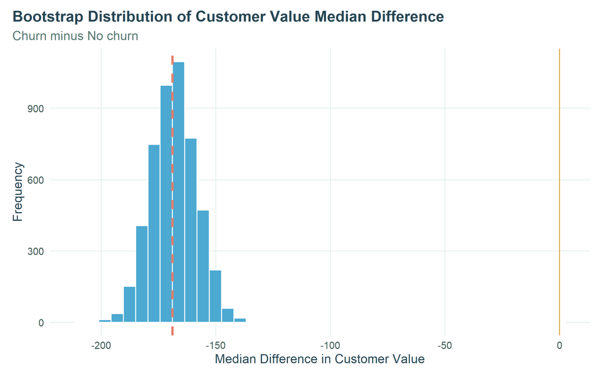

```r
print(plot_hist_difference(bootstrap_value$bootstrap_values,
  bootstrap_value$observed_difference,
  "Bootstrap Distribution of Customer Value Median Difference",
  "Churn minus No churn", "Median Difference in Customer Value"))
```

## 3.6 Gói cước và churn — Permutation Test

Kiểm định hoán vị **hai phía (10.000 lần)** xét chênh lệch tỷ lệ churn **Plan 1 − Plan 2**. Giả thuyết $H_0$: hai gói có cùng tỷ lệ churn.

```r
ab_data <- data |>
  transmute(
    tariff_plan,
    churn_binary = if_else(churn == "Churn", 1, 0)
  )

plan_levels <- levels(ab_data$tariff_plan)
plan_a <- plan_levels[1]
plan_b <- plan_levels[2]

ab_summary <- ab_data |>
  group_by(tariff_plan) |>
  summarise(
    Sample_Size = n(),
    Churn_Count = sum(churn_binary),
    Churn_Rate = mean(churn_binary),
    .groups = "drop"
  )

plan_a_rate <- ab_summary$Churn_Rate[
  ab_summary$tariff_plan == plan_a
]
plan_b_rate <- ab_summary$Churn_Rate[
  ab_summary$tariff_plan == plan_b
]

observed_ab_difference <- plan_a_rate - plan_b_rate

set.seed(analysis_seed)
number_of_permutations <- 10000

permuted_ab_differences <- replicate(number_of_permutations, {
  permuted_plan <- sample(ab_data$tariff_plan, replace = FALSE)
  mean(ab_data$churn_binary[permuted_plan == plan_a]) -
    mean(ab_data$churn_binary[permuted_plan == plan_b])
})
permutation_p_value <-
  (sum(abs(permuted_ab_differences) >= abs(observed_ab_difference)) + 1) /
  (number_of_permutations + 1)

ab_relative_risk <- plan_a_rate / plan_b_rate
ab_odds_ratio <-
  (plan_a_rate / (1 - plan_a_rate)) /
  (plan_b_rate / (1 - plan_b_rate))

# Fisher exact cho cùng giả thuyết khi nhóm Plan 2 rất ít trường hợp churn.
# Đây là phép đối chiếu độ nhạy, không phải giả thuyết độc lập bổ sung.
plan_contingency <- table(ab_data$tariff_plan, ab_data$churn_binary)
plan_fisher_p <- stats::fisher.test(plan_contingency)$p.value

permutation_results <- tibble(
  Statistic = c(
    "Observed difference: Plan 1 - Plan 2",
    "Permutation p-value",
    "Fisher exact p-value (same comparison)",
    "Relative Risk: Plan 1 / Plan 2",
    "Odds Ratio: Plan 1 / Plan 2",
    "Number of permutations"
  ),
  Value = c(
    observed_ab_difference,
    permutation_p_value,
    plan_fisher_p,
    ab_relative_risk,
    ab_odds_ratio,
    number_of_permutations
  )
)

render_analysis(list(ab_summary, permutation_results),
  c("Churn Rate by Tariff Plan", "Permutation Test: tỷ lệ churn theo gói cước"),
  paste0("<b>Chênh lệch Plan 1 − Plan 2:</b> ",
    num(100 * observed_ab_difference, 2), " điểm phần trăm; ",
    "p-value hoán vị ", formatC(permutation_p_value, digits = 5, format = "f"),
    ". Plan 2 chỉ có ", ab_summary$Churn_Count[ab_summary$tariff_plan == plan_b],
    " ca churn; RR và OR vì thế kém ổn định."), digits = 4)
```

Churn Rate by Tariff Plan

| tariff_plan | Sample_Size | Churn_Count | Churn_Rate |
| --- | --- | --- | --- |
| Plan 1 | 2621 | 440 | 0.1679 |
| Plan 2 | 229 | 6 | 0.0262 |

Permutation Test: tỷ lệ churn theo gói cước

| Statistic | Value |
| --- | --- |
| Observed difference: Plan 1 - Plan 2 | 0.1417 |
| Permutation p-value | 0.0001 |
| Fisher exact p-value (same comparison) | 0.0000 |
| Relative Risk: Plan 1 / Plan 2 | 6.4072 |
| Odds Ratio: Plan 1 / Plan 2 | 7.4981 |
| Number of permutations | 10000.0000 |

**Chênh lệch Plan 1 − Plan 2:** 14,17 điểm phần trăm; p-value hoán vị 0.00010. Plan 2 chỉ có 6 ca churn; RR và OR vì thế kém ổn định.

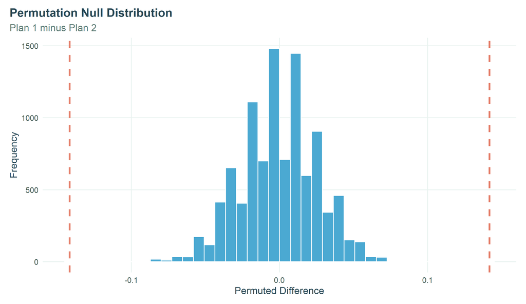

```r
plot_hist_difference(permuted_ab_differences, observed_ab_difference,
  "Permutation Null Distribution", "Plan 1 minus Plan 2",
  "Permuted Difference", permutation = TRUE)
```

## 3.7 Tần suất sử dụng theo trạng thái churn — Permutation Test

Ta so sánh **số lần sử dụng trung bình** giữa hai nhóm qua chênh lệch **Churn − No churn**. Kiểm định hoán vị **hai phía (10.000 lần)** xét giả thuyết tần suất sử dụng không gắn với trạng thái churn.

```r
permutation_mean_difference <- function(dataset, group_var, value_var,
                                        group_1, group_0, R = 10000, seed = analysis_seed) {
  d <- dataset |>
    dplyr::transmute(group = as.character({{ group_var }}),
                     value = as.numeric({{ value_var }})) |>
    dplyr::filter(!is.na(group), is.finite(value), group %in% c(group_0, group_1))
  if (!all(c(group_1, group_0) %in% d$group)) stop("Thiếu nhóm để hoán vị")
  summary <- d |>
    dplyr::group_by(group) |>
    dplyr::summarise(Sample_Size = dplyr::n(), Mean = mean(value),
                     Median = median(value), Standard_Deviation = sd(value),
                     IQR = IQR(value), .groups = "drop")
  observed <- mean(d$value[d$group == group_1]) - mean(d$value[d$group == group_0])
  # Giữ nguyên nhãn và số lượng trong mỗi nhóm, hoán vị giá trị sử dụng.
  idx_1 <- which(d$group == group_1)
  idx_0 <- which(d$group == group_0)
  set.seed(seed)
  differences <- replicate(R, {
    permuted <- sample(d$value, size = nrow(d), replace = FALSE)
    mean(permuted[idx_1]) - mean(permuted[idx_0])
  })
  extreme <- sum(abs(differences) >= abs(observed))
  p_value <- (extreme + 1) / (R + 1)
  mc_ci <- stats::binom.test(extreme, R, conf.level = .99)$conf.int
  list(group_summary = summary, observed_difference = observed,
       permutation_differences = differences, permutation_p_value = p_value,
       monte_carlo_ci = mc_ci,
       result_table = tibble::tibble(
         Statistic = c("Observed mean difference", "Permutation p-value",
                       "MC uncertainty 99% - lower", "MC uncertainty 99% - upper",
                       "Number of permutations"),
         Value = c(observed, p_value, mc_ci[1], mc_ci[2], R)))
}

permutation_usage <- permutation_mean_difference(
  data, churn, frequency_of_use, "Churn", "No churn", R = 10000,
  seed = analysis_seed)
usage_means <- stats::setNames(permutation_usage$group_summary$Mean,
                               permutation_usage$group_summary$group)
render_analysis(
  list(permutation_usage$group_summary, permutation_usage$result_table),
  c("Frequency of Use by Churn Status", "Permutation Test: Frequency of Use"),
  paste0("<b>Số lượt trung bình:</b> churn ", num(usage_means[["Churn"]], 2),
    "; không churn ", num(usage_means[["No churn"]], 2),
    ". <b>Chênh lệch:</b> ", num(permutation_usage$observed_difference, 2),
    " lượt; <b>p hoán vị:</b> ",
    format.pval(permutation_usage$permutation_p_value, digits = 4, eps = .0001), "."),
  digits = 4)
```

Frequency of Use by Churn Status

| group | Sample_Size | Mean | Median | Standard_Deviation | IQR |
| --- | --- | --- | --- | --- | --- |
| Churn | 446 | 30.6973 | 29 | 26.0911 | 39.75 |
| No churn | 2404 | 77.8665 | 64 | 58.5840 | 73.00 |

Permutation Test: Frequency of Use

| Statistic | Value |
| --- | --- |
| Observed mean difference | -47.1692 |
| Permutation p-value | 0.0001 |
| MC uncertainty 99% - lower | 0.0000 |
| MC uncertainty 99% - upper | 0.0005 |
| Number of permutations | 10000.0000 |

**Số lượt trung bình:** churn 30,70; không churn 77,87. **Chênh lệch:** -47,17 lượt; **p hoán vị:** < 0.0001.

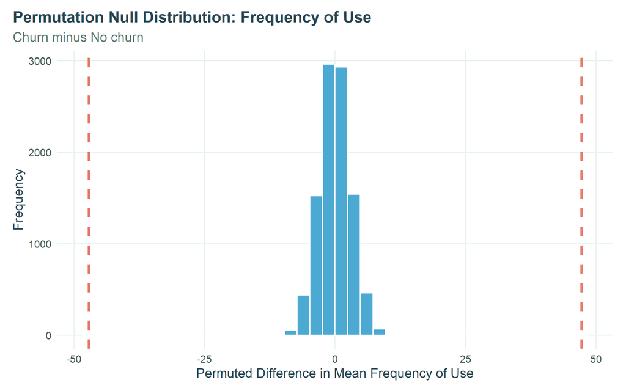

```r
print(plot_hist_difference(permutation_usage$permutation_differences,
  permutation_usage$observed_difference,
  "Permutation Null Distribution: Frequency of Use",
  "Churn minus No churn", "Permuted Difference in Mean Frequency of Use",
  permutation = TRUE))
```

## 3.8 Tổng hợp kiểm định hoán vị

Hai p-value hoán vị được **điều chỉnh Holm** vì ta xét đồng thời gói cước và tần suất sử dụng.

```r
permutation_holm_summary <- tibble::tibble(
  Comparison = c("Plan 1 vs Plan 2", "Frequency: churn vs no churn"),
  `Difference` = c(observed_ab_difference, permutation_usage$observed_difference),
  Unit = c("proportion", "uses"),
  `Permutation p-value` = c(permutation_p_value, permutation_usage$permutation_p_value)
) |>
  dplyr::mutate(
    `Holm-adjusted p-value` = p.adjust(`Permutation p-value`, method = "holm"),
    `Significant at 5% after Holm` =
      if_else(`Holm-adjusted p-value` < 0.05, "Yes", "No")
  )

knitr::kable(
  permutation_holm_summary,
  digits = 4,
  caption = "Permutation Tests — Raw and Holm-adjusted p-values"
) |>
  kableExtra::kable_styling(
    bootstrap_options = c("striped", "hover"), full_width = FALSE
  )
```

Permutation Tests — Raw and Holm-adjusted p-values

| Comparison | Difference | Unit | Permutation p-value | Holm-adjusted p-value | Significant at 5% after Holm |
| --- | --- | --- | --- | --- | --- |
| Plan 1 vs Plan 2 | 0.1417 | proportion | 0.0001 | 0.0002 | Yes |
| Frequency: churn vs no churn | -47.1692 | uses | 0.0001 | 0.0002 | Yes |

- **Gói cước:** Plan 1 − Plan 2 = **14,17 điểm phần trăm**; p-value Holm = **0,0002**.
- **Tần suất sử dụng:** Churn − No churn = **-47,17 lượt**; p-value Holm = **0,0002**.

## 3.9 Độ nhạy với việc loại dòng trùng

Ta tính lại bốn chênh lệch trên **3.150 dòng gốc** và **2.850 dòng sau loại trùng**, với cùng số lần lấy mẫu và seed. Ta đối chiếu chiều chênh lệch, khoảng tin cậy và p-value.

```r
# Bootstrap 1 — khiếu nại; cùng cách lấy mẫu phân tầng như phân tích chính.
complaint_raw <- data_before_dedup |>
  dplyr::transmute(complains, churn_binary = as.integer(churn == "Churn"))
set.seed(analysis_seed)
bootstrap_complaint_raw <- boot::boot(
  complaint_raw, bootstrap_complaint_stat, R = 5000, strata = complaint_raw$complains)
complaint_raw_ci <- unname(stats::quantile(as.numeric(bootstrap_complaint_raw$t),
                                            c(.025, .975)))
complaint_raw_diff <- complaint_diff(complaint_raw)

# Bootstrap 2 — trung vị customer_value.
bootstrap_value_raw <- bootstrap_difference_median(
  data_before_dedup, churn, customer_value, "Churn", "No churn",
  R = 5000, seed = analysis_seed)

# Permutation 1 — gói cước (nhãn churn giữ cố định, hoán vị gói cước).
plan_raw <- data_before_dedup |>
  dplyr::transmute(tariff_plan, churn_binary = as.integer(churn == "Churn"))
raw_plan_a_rate <- mean(plan_raw$churn_binary[plan_raw$tariff_plan == plan_a])
raw_plan_b_rate <- mean(plan_raw$churn_binary[plan_raw$tariff_plan == plan_b])
raw_plan_difference <- raw_plan_a_rate - raw_plan_b_rate
set.seed(analysis_seed)
raw_plan_permutations <- replicate(number_of_permutations, {
  group_perm <- sample(plan_raw$tariff_plan, replace = FALSE)
  mean(plan_raw$churn_binary[group_perm == plan_a]) -
    mean(plan_raw$churn_binary[group_perm == plan_b])
})
raw_plan_p <- (sum(abs(raw_plan_permutations) >= abs(raw_plan_difference)) + 1) /
  (number_of_permutations + 1)
raw_plan_fisher_p <- stats::fisher.test(
  table(plan_raw$tariff_plan, plan_raw$churn_binary))$p.value

# Permutation 2 — trung bình frequency_of_use.
permutation_usage_raw <- permutation_mean_difference(
  data_before_dedup, churn, frequency_of_use, "Churn", "No churn",
  R = 10000, seed = analysis_seed)

format_boot <- function(est, ci, factor = 1, suffix = "")
  paste0(num(est * factor, 2), suffix, "; CI 95% [",
         num(ci[1] * factor, 2), "; ", num(ci[2] * factor, 2), "]")
format_perm <- function(est, p, factor = 1, suffix = "")
  paste0(num(est * factor, 2), suffix, "; p = ",
         format.pval(p, digits = 3, eps = .0001))

sensitivity_table <- tibble::tibble(
  Analysis = c("Bootstrap: khiếu nại (pp)", "Bootstrap: customer_value",
               "Permutation: gói cước (pp)", "Permutation: frequency_of_use"),
  `Raw (3,150 rows)` = c(
    format_boot(complaint_raw_diff, complaint_raw_ci, 100, " pp"),
    format_boot(bootstrap_value_raw$observed_difference,
                bootstrap_value_raw$confidence_interval),
    paste0(format_perm(raw_plan_difference, raw_plan_p, 100, " pp"),
           "; Fisher p = ", format.pval(raw_plan_fisher_p, digits = 3, eps = .0001)),
    format_perm(permutation_usage_raw$observed_difference,
                permutation_usage_raw$permutation_p_value)),
  `Deduplicated (2,850 rows)` = c(
    format_boot(observed_complaint_difference, bootstrap_complaint_ci, 100, " pp"),
    format_boot(bootstrap_value$observed_difference, bootstrap_value$confidence_interval),
    paste0(format_perm(observed_ab_difference, permutation_p_value, 100, " pp"),
           "; Fisher p = ", format.pval(plan_fisher_p, digits = 3, eps = .0001)),
    format_perm(permutation_usage$observed_difference,
                permutation_usage$permutation_p_value))
)
cat(as.character(knitr::kable(
  sensitivity_table, format = "html", row.names = FALSE,
  caption = "Sensitivity to Duplicate Removal — Estimates, CIs and Raw p-values",
  table.attr = 'class="table table-striped pca-table"')))
```

Sensitivity to Duplicate Removal — Estimates, CIs and Raw p-values

| Analysis | Raw (3,150 rows) | Deduplicated (2,850 rows) |
| --- | --- | --- |
| Bootstrap: khiếu nại (pp) | 72,85 pp; CI 95% [67,94; 77,61] | 72,84 pp; CI 95% [67,85; 77,69] |
| Bootstrap: customer_value | -171,23; CI 95% [-188,50; -153,63] | -168,97; CI 95% [-187,24; -148,88] |
| Permutation: gói cước (pp) | 14,38 pp; p = <0.0001; Fisher p = <0.0001 | 14,17 pp; p = <0.0001; Fisher p = <0.0001 |
| Permutation: frequency_of_use | -47,85; p = <0.0001 | -47,17; p = <0.0001 |

```r
same_sign <- function(a, b) sign(a) == sign(b)
raw_perm_holm <- stats::p.adjust(
  c(raw_plan_p, permutation_usage_raw$permutation_p_value), method = "holm")
clean_perm_holm <- permutation_holm_summary[["Holm-adjusted p-value"]]
all_same_direction <- all(c(
  same_sign(complaint_raw_diff, observed_complaint_difference),
  same_sign(bootstrap_value_raw$observed_difference, bootstrap_value$observed_difference),
  same_sign(raw_plan_difference, observed_ab_difference),
  same_sign(permutation_usage_raw$observed_difference, permutation_usage$observed_difference)))
same_holm_conclusion <- all((raw_perm_holm < .05) == (clean_perm_holm < .05))
cat("<p><b>Sau khi loại trùng:</b> ",
    if (all_same_direction) "Cả bốn chênh lệch giữ nguyên chiều" else "Có chênh lệch đổi chiều",
    "; hai kiểm định hoán vị sau Holm ",
    if (same_holm_conclusion) "giữ nguyên kết luận ở mức 5%" else "thay đổi kết luận ở mức 5%",
    ".</p>\n", sep = "")
```

**Sau khi loại trùng:** Cả bốn chênh lệch giữ nguyên chiều; hai kiểm định hoán vị sau Holm giữ nguyên kết luận ở mức 5%.

*Bảng độ nhạy ghi p-value thô; phần kết luận kiểm định dùng p-value Holm. Những chênh lệch này không hàm ý quan hệ nhân quả.*

# 4 Xây dựng mô hình dự báo

Ba mô hình Logistic được so sánh:

- **Full:** 7 biến về mức sử dụng và thời gian đăng ký.
- **Reduced:** chọn biến từ Full theo **AIC trên train**.
- **Expanded:** thêm `complains`, `tariff_plan`, `status` và `age` để kiểm tra phần thông tin tăng thêm.

Ta không đưa `age_group` cùng `age` để tránh lặp thông tin; `charge_amount` chưa đủ rõ để đưa vào mô hình. Chia mẫu **80/20 phân tầng**, **5-fold CV**, seed **2026**.

## 4.1 Chuẩn bị dữ liệu cho mô hình

```r
model_predictors_usage <- c(
  "call_failure", "subscription_length", "seconds_of_use",
  "frequency_of_use", "frequency_of_sms",
  "distinct_called_numbers", "customer_value"
)
model_predictors_expanded <- c(
  model_predictors_usage,
  "complains", "tariff_plan", "status", "age"
)

classification_precheck <- data |>
  dplyr::mutate(churn_binary = as.integer(churn == "Churn")) |>
  dplyr::select(churn_binary, dplyr::all_of(model_predictors_expanded))
missing_model_cols <- vapply(classification_precheck, function(x) sum(is.na(x)), integer(1))
model_rows_missing <- sum(!stats::complete.cases(classification_precheck))
model_churn_before <- mean(classification_precheck$churn_binary == 1, na.rm = TRUE)
if (model_rows_missing > 0L) {
  stop("Phát hiện ", model_rows_missing, " hồ sơ thiếu biến mô hình. ",
       "Để tránh mất dữ liệu và leakage khi làm CV, cần triển khai ",
       "imputation theo từng fold train trước khi tiếp tục.")
}
classification_data <- classification_precheck
model_churn_after <- mean(classification_data$churn_binary == 1)

stopifnot(
  all(classification_data$churn_binary %in% c(0L, 1L)),
  length(unique(classification_data$churn_binary)) == 2L
)

classification_data |>
  dplyr::count(churn_binary, name = "Customers") |>
  dplyr::mutate(
    Churn = ifelse(churn_binary == 1, "Churn", "No churn"),
    Proportion = scales::percent(Customers / sum(Customers), accuracy = 0.1)
  ) |>
  dplyr::select(Churn, Customers, Proportion) |>
  knitr::kable(caption = "Class Distribution for Modeling",
    table.attr = 'class="table table-striped pca-table model-prep-table"') |>
  kableExtra::kable_styling(bootstrap_options = c("striped", "hover"),
                            full_width = FALSE) |>
  kableExtra::column_spec(2, bold = TRUE)
```

Class Distribution for Modeling

| Churn | Customers | Proportion |
| --- | --- | --- |
| No churn | 2404 | 84.4% |
| Churn | 446 | 15.6% |

Cả **2850 hồ sơ** đều được giữ để chia mẫu; **0 hồ sơ thiếu biến mô hình**. Tỷ lệ churn: **15.65%**.

## 4.2 Chia tập train/test

```r
classification_data <- classification_data |>
  dplyr::mutate(observation_id = dplyr::row_number())

set.seed(analysis_seed)
train_ids <- classification_data |>
  dplyr::group_by(churn_binary) |>
  dplyr::slice_sample(prop = 0.80) |>
  dplyr::ungroup() |>
  dplyr::pull(observation_id)

stopifnot(length(unique(train_ids)) == length(train_ids),
          all(train_ids %in% classification_data$observation_id))
train_model_data <- classification_data |>
  dplyr::filter(observation_id %in% train_ids) |>
  dplyr::select(-observation_id)

test_model_data <- classification_data |>
  dplyr::filter(!observation_id %in% train_ids) |>
  dplyr::select(-observation_id)
stopifnot(nrow(train_model_data) + nrow(test_model_data) == nrow(classification_data),
          all(vapply(list(train_model_data, test_model_data),
                     function(d) all(d$churn_binary %in% c(0L, 1L)), logical(1))))

split_summary <- dplyr::bind_rows(
  train_model_data |>
    dplyr::count(churn_binary) |>
    dplyr::mutate(Dataset = "Train"),
  test_model_data |>
    dplyr::count(churn_binary) |>
    dplyr::mutate(Dataset = "Test")
) |>
  dplyr::group_by(Dataset) |>
  dplyr::mutate(Proportion = n / sum(n)) |>
  dplyr::ungroup()

split_summary |>
  dplyr::mutate(
    Churn = ifelse(churn_binary == 1, "Churn", "No churn"),
    Proportion = scales::percent(Proportion, accuracy = 0.1)
  ) |>
  dplyr::select(Dataset, Churn, Customers = n, Proportion) |>
  knitr::kable(caption = "Stratified 80/20 Train–Test Split",
    table.attr = 'class="table table-striped pca-table train-test-table"') |>
  kableExtra::kable_styling(bootstrap_options = c("striped", "hover"),
                            full_width = FALSE) |>
  kableExtra::column_spec(3, bold = TRUE)
```

Stratified 80/20 Train–Test Split

| Dataset | Churn | Customers | Proportion |
| --- | --- | --- | --- |
| Train | No churn | 1923 | 84.4% |
| Train | Churn | 356 | 15.6% |
| Test | No churn | 481 | 84.2% |
| Test | Churn | 90 | 15.8% |

**Train:** 2279 hồ sơ, 356 churn. **Test:** 571 hồ sơ, 90 churn.

## 4.3 Full Logistic — bảy biến sử dụng

```r
full_formula <- stats::reformulate(
  model_predictors_usage, response = "churn_binary"
)
logistic_full <- stats::glm(
  formula = full_formula,
  data = train_model_data,
  family = stats::binomial(link = "logit"),
  control = stats::glm.control(maxit = 100)
)
summary(logistic_full)
```

```
##
## Call:
## stats::glm(formula = full_formula, family = stats::binomial(link = "logit"),
##     data = train_model_data, control = stats::glm.control(maxit = 100))
##
## Coefficients:
##                            Estimate  Std. Error z value    Pr(>|z|)
## (Intercept)             -0.06552120  0.25012969  -0.262    0.793361
## call_failure             0.16025166  0.01425776  11.240     < 2e-16 ***
## subscription_length     -0.00989796  0.00756490  -1.308    0.190735
## seconds_of_use          -0.00020670  0.00007667  -2.696    0.007018 **
## frequency_of_use        -0.03733612  0.00703731  -5.305 0.000000112 ***
## frequency_of_sms        -0.02657374  0.00722557  -3.678    0.000235 ***
## distinct_called_numbers -0.00719520  0.00759882  -0.947    0.343698
## customer_value           0.00366428  0.00165601   2.213    0.026918 *
## ---
## Signif. codes:  0 '***' 0.001 '**' 0.01 '*' 0.05 '.' 0.1 ' ' 1
##
## (Dispersion parameter for binomial family taken to be 1)
##
##     Null deviance: 1975.1  on 2278  degrees of freedom
## Residual deviance: 1400.0  on 2271  degrees of freedom
## AIC: 1416
##
## Number of Fisher Scoring iterations: 7
```

**OR** cho biết odds churn thay đổi bao nhiêu lần khi một biến tăng một đơn vị, giữ các biến khác không đổi. OR của những biến khác đơn vị **không so sánh trực tiếp**.

```r
full_or_table <- broom::tidy(logistic_full) |>
  dplyr::mutate(
    Odds_Ratio = exp(estimate),
    `OR 95% lower` = exp(estimate - 1.96 * std.error),
    `OR 95% upper` = exp(estimate + 1.96 * std.error)
  ) |>
  dplyr::select(Predictor = term, Odds_Ratio,
                `OR 95% lower`, `OR 95% upper`, p.value)
knitr::kable(full_or_table, digits = 4,
    caption = "Odds Ratio — Full Logistic trên tập train",
    table.attr = 'class="table table-striped pca-table"') |>
  kableExtra::kable_styling(
    bootstrap_options = c("striped", "hover"), full_width = FALSE)
```

Odds Ratio — Full Logistic trên tập train

| Predictor | Odds_Ratio | OR 95% lower | OR 95% upper | p.value |
| --- | --- | --- | --- | --- |
| (Intercept) | 0.9366 | 0.5736 | 1.5292 | 0.7934 |
| call_failure | 1.1738 | 1.1415 | 1.2071 | 0.0000 |
| subscription_length | 0.9902 | 0.9756 | 1.0049 | 0.1907 |
| seconds_of_use | 0.9998 | 0.9996 | 0.9999 | 0.0070 |
| frequency_of_use | 0.9634 | 0.9502 | 0.9767 | 0.0000 |
| frequency_of_sms | 0.9738 | 0.9601 | 0.9877 | 0.0002 |
| distinct_called_numbers | 0.9928 | 0.9782 | 1.0077 | 0.3437 |
| customer_value | 1.0037 | 1.0004 | 1.0069 | 0.0269 |

Bảng dùng **CI Wald 95%**; hệ số Logistic không thể xem là tác động nhân quả.

### 4.3.1 Kiểm tra đa cộng tuyến trên train

```r
vif_values <- car::vif(logistic_full)
vif_table <- tibble::tibble(
  Variable = names(vif_values),
  VIF = as.numeric(vif_values)
) |>
  dplyr::arrange(dplyr::desc(VIF))
compact_table_with_note(vif_table,
  "Variance Inflation Factor — Usage-only Logistic", paste0(
  "<strong>Nhận xét</strong><ul>",
  "<li>VIF lớn nhất <b>", num(max(vif_table$VIF), 2), "</b> ở biến <b>",
  vif_table$Variable[which.max(vif_table$VIF)], "</b>.</li>",
  "<li>", if (max(vif_table$VIF) >= 10) {
    "VIF trên 10; hệ số của từng biến có thể biến động mạnh."
  } else if (max(vif_table$VIF) >= 5) {
    "Có VIF từ 5 trở lên; cần đọc hệ số cùng các biến tương quan."
  } else { "VIF chưa vượt ngưỡng tham khảo 5." }, "</li>",
  "</ul>"), digits = 2)
```

Variance Inflation Factor — Usage-only Logistic

| Variable | VIF |
| --- | --- |
| customer_value | 19.43 |
| frequency_of_sms | 14.15 |
| frequency_of_use | 8.16 |
| seconds_of_use | 4.81 |
| distinct_called_numbers | 2.18 |
| call_failure | 1.94 |
| subscription_length | 1.06 |

**Nhận xét**

- VIF lớn nhất **19,43** ở biến **customer_value**.
- VIF trên 10; hệ số của từng biến có thể biến động mạnh.

## 4.4 Reduced Logistic — lựa chọn theo AIC

```r
logistic_reduced <- stats::step(
  logistic_full, direction = "both", trace = 0
)

reduced_terms <- attr(stats::terms(logistic_reduced), "term.labels")
comparison_aic <- tibble::tibble(
  Model = c("Full Logistic", "Reduced Logistic"),
  Number_of_predictors = c(
    length(model_predictors_usage), length(reduced_terms)
  ),
  AIC_train = c(AIC(logistic_full), AIC(logistic_reduced)),
  Residual_deviance_train = c(
    stats::deviance(logistic_full), stats::deviance(logistic_reduced)
  )
)
knitr::kable(comparison_aic, digits = 3,
  caption = "Model Size and Fit — Training Data")
```

Model Size and Fit — Training Data

| Model | Number_of_predictors | AIC_train | Residual_deviance_train |
| --- | --- | --- | --- |
| Full Logistic | 7 | 1415.998 | 1399.998 |
| Reduced Logistic | 5 | 1414.592 | 1402.592 |

```r
formula(logistic_reduced)
## churn_binary ~ call_failure + seconds_of_use + frequency_of_use +
##     frequency_of_sms + customer_value
```

```r
reduced_coefficients <- broom::tidy(logistic_reduced) |>
  dplyr::mutate(
    Odds_Ratio = exp(estimate),
    OR_CI_lower = exp(estimate - 1.96 * std.error),
    OR_CI_upper = exp(estimate + 1.96 * std.error)
  ) |>
  dplyr::select(term, estimate, Odds_Ratio,
    OR_CI_lower, OR_CI_upper, p.value)

knitr::kable(
  reduced_coefficients, digits = 4,
  col.names = c("Predictor", "Log-odds", "Odds Ratio",
                "OR 95% lower", "OR 95% upper", "Wald p-value"),
  caption = "Reduced Logistic Coefficients (exploratory)"
) |>
  kableExtra::kable_styling(
    bootstrap_options = c("striped", "hover"), full_width = FALSE
  )
```

Reduced Logistic Coefficients (exploratory)

| Predictor | Log-odds | Odds Ratio | OR 95% lower | OR 95% upper | Wald p-value |
| --- | --- | --- | --- | --- | --- |
| (Intercept) | -0.3814 | 0.6829 | 0.5515 | 0.8457 | 0.0005 |
| call_failure | 0.1600 | 1.1736 | 1.1414 | 1.2067 | 0.0000 |
| seconds_of_use | -0.0002 | 0.9998 | 0.9996 | 0.9999 | 0.0054 |
| frequency_of_use | -0.0414 | 0.9595 | 0.9477 | 0.9714 | 0.0000 |
| frequency_of_sms | -0.0289 | 0.9715 | 0.9585 | 0.9848 | 0.0000 |
| customer_value | 0.0042 | 1.0042 | 1.0011 | 1.0073 | 0.0077 |

Trên train, **AIC giảm từ 1.416,00 xuống 1.414,59** sau khi rút gọn. Reduced còn **5/7 biến**: call_failure, seconds_of_use, frequency_of_use, frequency_of_sms, customer_value.

**AIC không đo chất lượng dự báo trên test.** P-value sau lựa chọn biến theo AIC chỉ dùng tham khảo.

## 4.5 Expanded Logistic — bổ sung thông tin tài khoản

```r
expanded_formula <- stats::reformulate(
  model_predictors_expanded, response = "churn_binary"
)
logistic_expanded <- stats::glm(
  formula = expanded_formula,
  data = train_model_data,
  family = stats::binomial(link = "logit"),
  control = stats::glm.control(maxit = 100)
)

expanded_fit_table <- tibble::tibble(
  Model = c("Full usage-only", "Reduced AIC", "Expanded"),
  Number_of_predictors = c(
    length(model_predictors_usage), length(reduced_terms),
    length(model_predictors_expanded)
  ),
  AIC_train = c(
    AIC(logistic_full), AIC(logistic_reduced), AIC(logistic_expanded)
  )
)
compact_table_with_note(expanded_fit_table,
  "Training AIC of Three Logistic Models", paste0(
    "<b>AIC</b> phản ánh độ khớp train có phạt số biến; không bảo đảm AP trên test cao hơn."), digits = 2)
```

Training AIC of Three Logistic Models

| Model | Number_of_predictors | AIC_train |
| --- | --- | --- |
| Full usage-only | 7 | 1416.00 |
| Reduced AIC | 5 | 1414.59 |
| Expanded | 11 | 1004.56 |

**AIC** phản ánh độ khớp train có phạt số biến; không bảo đảm AP trên test cao hơn.

**AIC trên train:** Expanded **1.004,56**, Full **1.416,00**, Reduced **1.414,59**. Kết quả Expanded chỉ **tham khảo** do chưa rõ thời điểm ghi nhận `status`.

### 4.5.1 Kiểm tra Expanded: đa cộng tuyến và độ nhạy với `status`

```r
expanded_vif_raw <- tryCatch(car::vif(logistic_expanded), error = function(e) e)
if (inherits(expanded_vif_raw, "error")) {
  cat("<p>Không tính được VIF của Expanded: ",
      conditionMessage(expanded_vif_raw), "</p>", sep = "")
} else {
  if (is.matrix(expanded_vif_raw)) {
    expanded_vif_table <- tibble::tibble(
      Variable = rownames(expanded_vif_raw),
      GVIF = as.numeric(expanded_vif_raw[, "GVIF"]),
      Df = as.numeric(expanded_vif_raw[, "Df"]),
      `Adjusted GVIF` = as.numeric(expanded_vif_raw[, "GVIF^(1/(2*Df))"])
    )
  } else {
    expanded_vif_table <- tibble::tibble(
      Variable = names(expanded_vif_raw),
      VIF = as.numeric(expanded_vif_raw),
      `Adjusted GVIF` = sqrt(as.numeric(expanded_vif_raw))
    )
  }
  expanded_vif_table <- dplyr::arrange(expanded_vif_table,
                                       dplyr::desc(`Adjusted GVIF`))
  cat(as.character(tab(expanded_vif_table,
    "VIF / GVIF điều chỉnh của Expanded trên train", digits = 2)))
}
```

VIF / GVIF điều chỉnh của Expanded trên train

| Variable | VIF | Adjusted GVIF |
| --- | --- | --- |
| customer_value | 53,29 | 7,30 |
| frequency_of_sms | 33,18 | 5,76 |
| frequency_of_use | 12,79 | 3,58 |
| seconds_of_use | 11,47 | 3,39 |
| distinct_called_numbers | 2,88 | 1,70 |
| call_failure | 2,18 | 1,48 |
| age | 2,13 | 1,46 |
| status | 1,73 | 1,32 |
| tariff_plan | 1,41 | 1,19 |
| complains | 1,31 | 1,15 |
| subscription_length | 1,27 | 1,13 |

```r
cook_full <- stats::cooks.distance(logistic_full)
cook_cutoff <- 4 / nrow(train_model_data)
cat("<p>Ở Full, có <strong>", sum(cook_full > cook_cutoff, na.rm = TRUE),
    "</strong> quan sát train vượt ngưỡng tham khảo Cook's D &gt; ",
    num(cook_cutoff, 4), ". Đây là chỉ dấu cần kiểm tra độ nhạy,",
    " không phải lý do để xóa hồ sơ.</p>", sep = "")
```

Ở Full, có **86** quan sát train vượt ngưỡng tham khảo Cook’s D > 0,0018. Đây là chỉ dấu cần kiểm tra độ nhạy, không phải lý do để xóa hồ sơ.

Ta dùng **GVIF đã điều chỉnh** cho biến nhiều mức; giá trị cao cho thấy hệ số có thể kém ổn định.

### 4.5.2 Kiểm tra tuyến tính trên thang log-odds

```r
linearity_candidates <- c("subscription_length", "seconds_of_use",
                          "frequency_of_use", "customer_value")
linearity_check <- purrr::map_dfr(linearity_candidates, function(v) {
  spline_term <- paste0("splines::ns(", v, ", df = 3)")
  alternative <- stats::reformulate(
    c(setdiff(model_predictors_usage, v), spline_term),
    response = "churn_binary"
  )
  fit <- tryCatch(stats::glm(alternative, data = train_model_data,
    family = stats::binomial(), control = stats::glm.control(maxit = 100)),
    error = function(e) NULL)
  if (is.null(fit)) return(tibble::tibble(
    Variable = v, LR = NA_real_, Df = NA_real_, `Exploratory p` = NA_real_))
  df_delta <- attr(stats::logLik(fit), "df") -
              attr(stats::logLik(logistic_full), "df")
  lr <- 2 * (as.numeric(stats::logLik(fit)) -
             as.numeric(stats::logLik(logistic_full)))
  tibble::tibble(Variable = v, LR = lr, Df = df_delta,
    `Exploratory p` = if (df_delta > 0) {
      stats::pchisq(max(0, lr), df = df_delta, lower.tail = FALSE)
    } else NA_real_)
})
tab(linearity_check, "Kiểm tra spline bậc tự do 3 so với Full tuyến tính (train)", digits = 4)
```

Kiểm tra spline bậc tự do 3 so với Full tuyến tính (train)

| Variable | LR | Df | Exploratory p |
| --- | --- | --- | --- |
| subscription_length | 112,3467 | 2,0000 | 0,0000 |
| seconds_of_use | 20,6069 | 2,0000 | 0,0000 |
| frequency_of_use | 2,1854 | 2,0000 | 0,3353 |
| customer_value | 7,3891 | 2,0000 | 0,0249 |

Thay từng biến liên tục bằng **natural spline (df = 3)**, có **3/4 biến** cho khác biệt đáng kể so với dạng tuyến tính ở mức 5%. Đây là kiểm tra thăm dò trên train; mô hình dự báo vẫn dùng biến gốc.

# 5 Đánh giá và lựa chọn mô hình

## 5.1 Các chỉ số và quy tắc lựa chọn

Churn chỉ chiếm **15.6%** ở train. Vì vậy, ta chọn mô hình theo **AP trên OOF**; nếu gần bằng nhau thì xét Balanced Accuracy, rồi Brier Score. ROC-AUC đo khả năng phân biệt; Brier đo sai số xác suất. Các chỉ số phân loại dùng ngưỡng Youden từ train.

```r
safe_divide <- function(a, b) {
  if (b == 0) return(NA_real_)
  as.numeric(a / b)
}

average_precision <- function(actual, probability) {
  if (length(actual) != length(probability)) {
    stop("actual và probability phải có cùng độ dài")
  }
  if (anyNA(actual) || anyNA(probability) ||
      any(!is.finite(probability))) {
    stop("AP cần nhãn và xác suất không khuyết")
  }
  if (sum(actual == 1) == 0L) return(NA_real_)
  ord <- order(probability, decreasing = TRUE)
  y <- as.integer(actual[ord] == 1)
  score <- probability[ord]
  # Kết thúc từng nhóm điểm có cùng xác suất để không phụ thuộc
  # vào thứ tự quan sát khi xuất hiện ties.
  end_idx <- which(!duplicated(score, fromLast = TRUE))
  recall <- cumsum(y)[end_idx] / sum(y)
  precision <- cumsum(y)[end_idx] / end_idx
  sum(diff(c(0, recall)) * precision)
}

classification_metrics <- function(actual, probability, threshold,
                                   model_name = "Model") {
  stopifnot(length(actual) == length(probability),
            all(actual %in% c(0L, 1L)),
            all(is.finite(probability)),
            length(threshold) == 1L, is.finite(threshold))
  predicted <- as.integer(probability >= threshold)
  cm <- table(
    Predicted = factor(predicted, levels = c(0, 1)),
    Actual = factor(actual, levels = c(0, 1))
  )
  tn <- unname(cm["0", "0"])
  fn <- unname(cm["0", "1"])
  fp <- unname(cm["1", "0"])
  tp <- unname(cm["1", "1"])
  sensitivity <- safe_divide(tp, tp + fn)
  specificity <- safe_divide(tn, tn + fp)
  precision <- safe_divide(tp, tp + fp)
  accuracy <- safe_divide(tp + tn, sum(cm))
  f1 <- safe_divide(2 * tp, 2 * tp + fp + fn)
  roc_obj <- pROC::roc(
    response = factor(actual, levels = c(0, 1)),
    predictor = probability,
    levels = c("0", "1"), direction = "<", quiet = TRUE
  )
  tibble::tibble(
    model = model_name, threshold = threshold,
    accuracy = accuracy, sensitivity = sensitivity,
    specificity = specificity, precision = precision,
    f1 = f1,
    balanced_accuracy = mean(c(sensitivity, specificity)),
    auc = as.numeric(pROC::auc(roc_obj)),
    average_precision = average_precision(actual, probability),
    brier = mean((probability - actual)^2),
    tn = as.integer(tn), fp = as.integer(fp),
    fn = as.integer(fn), tp = as.integer(tp)
  )
}

choose_youden <- function(actual, probability) {
  roc_obj <- pROC::roc(
    response = actual, predictor = probability,
    levels = c(0, 1), direction = "<", quiet = TRUE
  )
  best <- as.data.frame(pROC::coords(
    roc_obj, x = "best", best.method = "youden",
    ret = c("threshold", "sensitivity", "specificity"),
    transpose = FALSE
  ))
  # Nếu có nhiều điểm cùng J, lấy điểm có Specificity cao hơn
  # để giảm số cảnh báo sai; không nhìn vào test để giải tie.
  best <- best[order(-best$specificity, -best$threshold), , drop = FALSE]
  best[1, , drop = FALSE]
}
```

## 5.2 Cross-validation và quyết định trên train

```r
set.seed(analysis_seed)
n_folds <- 5L
fold_id <- integer(nrow(train_model_data))
for (class_id in c(0L, 1L)) {
  ix <- which(train_model_data$churn_binary == class_id)
  fold_id[ix] <- sample(rep(seq_len(n_folds), length.out = length(ix)))
}

fold_selected_terms <- vector("list", n_folds)
oof_predictions <- tibble::tibble(
  churn_binary = train_model_data$churn_binary,
  Full = rep(NA_real_, nrow(train_model_data)),
  Reduced = rep(NA_real_, nrow(train_model_data)),
  Expanded = rep(NA_real_, nrow(train_model_data))
)

for (k in seq_len(n_folds)) {
  fold_train <- train_model_data[fold_id != k, , drop = FALSE]
  fold_valid <- train_model_data[fold_id == k, , drop = FALSE]

  fit_full_fold <- stats::glm(
    full_formula, data = fold_train, family = stats::binomial(),
    control = stats::glm.control(maxit = 100)
  )
  # Chọn biến lại trên 4/5 train, KHÔNG sử dụng fold validation.
  fit_reduced_fold <- stats::step(
    fit_full_fold, direction = "both", trace = 0
  )
  fold_selected_terms[[k]] <- attr(stats::terms(fit_reduced_fold), "term.labels")
  fit_expanded_fold <- stats::glm(
    expanded_formula, data = fold_train, family = stats::binomial(),
    control = stats::glm.control(maxit = 100)
  )
  stopifnot(all(vapply(list(fit_full_fold, fit_reduced_fold, fit_expanded_fold),
                       function(fit) isTRUE(fit$converged), logical(1))))

  oof_predictions$Full[fold_id == k] <- stats::predict(
    fit_full_fold, newdata = fold_valid, type = "response"
  )
  oof_predictions$Reduced[fold_id == k] <- stats::predict(
    fit_reduced_fold, newdata = fold_valid, type = "response"
  )
  oof_predictions$Expanded[fold_id == k] <- stats::predict(
    fit_expanded_fold, newdata = fold_valid, type = "response"
  )
}

stopifnot(!anyNA(oof_predictions),
          all(is.finite(as.matrix(oof_predictions[, -1]))),
          all(as.matrix(oof_predictions[, -1]) >= 0 &
              as.matrix(oof_predictions[, -1]) <= 1))

model_names <- c("Full", "Reduced", "Expanded")
model_thresholds <- vapply(model_names, function(name) {
  as.numeric(choose_youden(oof_predictions$churn_binary,
                           oof_predictions[[name]])$threshold)
}, numeric(1))
cv_comparison <- purrr::map_dfr(model_names, function(name) {
  classification_metrics(oof_predictions$churn_binary,
                         oof_predictions[[name]], model_thresholds[[name]], name)
})

knitr::kable(
  cv_comparison |>
    dplyr::select(model, threshold, auc, average_precision, brier,
                  sensitivity, specificity, precision, f1,
                  balanced_accuracy) |>
    dplyr::mutate(dplyr::across(dplyr::where(is.numeric),
                   ~ round(.x, 3))),
  caption = "OOF Train Evaluation and Youden Thresholds — 5-fold CV"
) |>
  kableExtra::kable_styling(
    bootstrap_options = c("striped", "hover"), full_width = FALSE
  )
```

OOF Train Evaluation and Youden Thresholds — 5-fold CV

| model | threshold | auc | average_precision | brier | sensitivity | specificity | precision | f1 | balanced_accuracy |
| --- | --- | --- | --- | --- | --- | --- | --- | --- | --- |
| Full | 0.146 | 0.853 | 0.513 | 0.100 | 0.879 | 0.709 | 0.359 | 0.510 | 0.794 |
| Reduced | 0.146 | 0.853 | 0.514 | 0.100 | 0.893 | 0.701 | 0.356 | 0.509 | 0.797 |
| Expanded | 0.149 | 0.934 | 0.770 | 0.068 | 0.902 | 0.833 | 0.499 | 0.643 | 0.867 |

```r
# Quy tắc lựa chọn được ấn định trên train:
# ưu tiên Average Precision; hòa thì Balanced Accuracy, Brier.
cv_ranked <- cv_comparison |>
  dplyr::arrange(dplyr::desc(average_precision),
                 dplyr::desc(balanced_accuracy), brier)
selected_model <- cv_ranked$model[[1]]
selected_threshold <- model_thresholds[[selected_model]]
# Phương án không sử dụng các biến tài khoản: lựa chọn độc lập bằng OOF train.
cv_usage_ranked <- cv_comparison |>
  dplyr::filter(model %in% c("Full", "Reduced")) |>
  dplyr::arrange(dplyr::desc(average_precision),
                 dplyr::desc(balanced_accuracy), brier)
usage_selected_model <- cv_usage_ranked$model[[1]]
usage_selected_threshold <- model_thresholds[[usage_selected_model]]
stopifnot(usage_selected_model %in% c("Full", "Reduced"))
```

**Kết quả trên train (OOF):**

- **Mô hình dẫn đầu:** Expanded (AP **0,770**, ROC-AUC **0,934**, Brier **0,068**).
- **Ngưỡng Youden OOF:** **0,149**.
- **Phương án không dùng `status`:** Reduced (AP **0,514**, ngưỡng **0,146**).

AP OOF có thể hơi lạc quan vì cùng dữ liệu được dùng chọn mô hình và ngưỡng; **test không tham gia lựa chọn**.

### 5.2.1 Độ ổn định của biến được Reduced chọn

```r
reduced_selection <- tibble::tibble(
  Predictor = model_predictors_usage,
  `Folds selected` = vapply(model_predictors_usage, function(v) {
    sum(vapply(fold_selected_terms, function(z) v %in% z, logical(1)))
  }, integer(1))
)
tab(reduced_selection, "Số fold (trên 5) giữ mỗi biến trong Reduced AIC", digits = 0)
```

Số fold (trên 5) giữ mỗi biến trong Reduced AIC

| Predictor | Folds selected |
| --- | --- |
| call_failure | 5 |
| subscription_length | 2 |
| seconds_of_use | 5 |
| frequency_of_use | 5 |
| frequency_of_sms | 5 |
| distinct_called_numbers | 0 |
| customer_value | 5 |

### 5.2.2 Đối chiếu Expanded khi không dùng `status`

```r
no_status_formula <- stats::reformulate(
  setdiff(model_predictors_expanded, "status"), response = "churn_binary"
)
no_status_oof <- rep(NA_real_, nrow(train_model_data))
for (k in seq_len(n_folds)) {
  fit_no_status <- stats::glm(no_status_formula,
    data = train_model_data[fold_id != k, , drop = FALSE],
    family = stats::binomial(), control = stats::glm.control(maxit = 100))
  no_status_oof[fold_id == k] <- stats::predict(fit_no_status,
    newdata = train_model_data[fold_id == k, , drop = FALSE], type = "response")
}
stopifnot(all(is.finite(no_status_oof)))
status_ablation <- tibble::tibble(
  Model = c("Expanded", "Expanded without status"),
  `OOF Average Precision` = c(
    average_precision(oof_predictions$churn_binary, oof_predictions$Expanded),
    average_precision(oof_predictions$churn_binary, no_status_oof)),
  `OOF Brier` = c(mean((oof_predictions$Expanded - oof_predictions$churn_binary)^2),
                   mean((no_status_oof - oof_predictions$churn_binary)^2))
)
tab(status_ablation,
    "Độ nhạy khi bỏ status — chỉ đánh giá OOF trên train", digits = 3)
```

Độ nhạy khi bỏ status — chỉ đánh giá OOF trên train

| Model | OOF Average Precision | OOF Brier |
| --- | --- | --- |
| Expanded | 0,770 | 0,068 |
| Expanded without status | 0,761 | 0,070 |

Trên OOF train, bỏ `status` làm AP thay đổi từ **0,770** xuống **0,761**. Test không tham gia phép so sánh này.

## 5.3 Xác suất dự báo và ma trận nhầm lẫn trên test

```r
model_fits <- list(
  Full = logistic_full,
  Reduced = logistic_reduced,
  Expanded = logistic_expanded
)
stopifnot(all(vapply(model_fits, function(fit) isTRUE(fit$converged), logical(1))))
model_test_probabilities <- lapply(model_fits, function(fit) {
  prob <- stats::predict(fit, newdata = test_model_data, type = "response")
  stopifnot(all(is.finite(prob)), all(prob >= 0 & prob <= 1))
  prob
})

comparison_table <- purrr::imap_dfr(model_test_probabilities,
  function(probability, name) {
    classification_metrics(test_model_data$churn_binary, probability,
                           model_thresholds[[name]], name)
  }) |>
  dplyr::mutate(aic_train = vapply(model_fits, AIC, numeric(1)))

selected_result <- comparison_table |>
  dplyr::filter(model == selected_model)
```

#### Full Logistic

OOF Youden threshold: **0,146**

| Predicted / Actual | No churn | Churn |
| --- | --- | --- |
| No churn | 348 | 15 |
| Churn | 133 | 75 |

#### Reduced Logistic

OOF Youden threshold: **0,146**

| Predicted / Actual | No churn | Churn |
| --- | --- | --- |
| No churn | 345 | 14 |
| Churn | 136 | 76 |

#### Expanded Logistic

OOF Youden threshold: **0,149**

| Predicted / Actual | No churn | Churn |
| --- | --- | --- |
| No churn | 405 | 10 |
| Churn | 76 | 80 |

**Hàng là dự đoán, cột là thực tế.** Ô Churn–Churn là dự báo đúng; Churn–No churn là cảnh báo sai.

## 5.4 So sánh chỉ số dự báo trên test

```r
test_metric_order <- c(
  "AIC (train)" = "aic_train", "Threshold" = "threshold",
  "Accuracy" = "accuracy", "Sensitivity" = "sensitivity",
  "Specificity" = "specificity", "Precision" = "precision",
  "F1" = "f1", "Balanced Accuracy" = "balanced_accuracy",
  "ROC-AUC" = "auc", "Average Precision" = "average_precision",
  "Brier Score" = "brier", "True Negatives (TN)" = "tn",
  "False Positives (FP)" = "fp", "False Negatives (FN)" = "fn",
  "True Positives (TP)" = "tp"
)
test_metrics_vertical <- transpose_model_metrics(comparison_table, test_metric_order)
render_analysis(test_metrics_vertical,
  "Held-out Test — Fixed OOF Thresholds and Predictive Metrics",
  paste0("<strong>Nhận xét</strong><ul>",
    "<li><b>", selected_model, "</b> được chọn từ OOF train. Trên test, ROC-AUC = <b>",
    num(selected_result$auc, 3), "</b>, AP = <b>",
    num(selected_result$average_precision, 3), "</b>.</li>",
    "<li>Ta phát hiện <b>", selected_result$tp, " churn</b>, bỏ sót <b>",
    selected_result$fn, "</b> và cảnh báo sai <b>", selected_result$fp, "</b>.</li>",
    "</ul>"), metrics = TRUE)
```

Held-out Test — Fixed OOF Thresholds and Predictive Metrics

| Metric | Full | Reduced | Expanded |
| --- | --- | --- | --- |
| AIC (train) | 1416.0 | 1414.6 | 1004.6 |
| Threshold | 0.146 | 0.146 | 0.149 |
| Accuracy | 0.741 | 0.737 | 0.849 |
| Sensitivity | 0.833 | 0.844 | 0.889 |
| Specificity | 0.723 | 0.717 | 0.842 |
| Precision | 0.361 | 0.358 | 0.513 |
| F1 | 0.503 | 0.503 | 0.650 |
| Balanced Accuracy | 0.778 | 0.781 | 0.865 |
| ROC-AUC | 0.857 | 0.856 | 0.927 |
| Average Precision | 0.507 | 0.514 | 0.752 |
| Brier Score | 0.100 | 0.100 | 0.073 |
| True Negatives (TN) | 348 | 345 | 405 |
| False Positives (FP) | 133 | 136 | 76 |
| False Negatives (FN) | 15 | 14 | 10 |
| True Positives (TP) | 75 | 76 | 80 |

**Nhận xét**

- **Expanded** được chọn từ OOF train. Trên test, ROC-AUC = **0,927**, AP = **0,752**.
- Ta phát hiện **80 churn**, bỏ sót **10** và cảnh báo sai **76**.

*AIC thuộc train; các chỉ số còn lại thuộc test. ROC-AUC và AP không phụ thuộc ngưỡng.*

## 5.5 Đối chiếu ngưỡng 0,50 và Youden

```r
selected_prob <- model_test_probabilities[[selected_model]]
threshold_comparison <- dplyr::bind_rows(
  classification_metrics(test_model_data$churn_binary, selected_prob, 0.50,
    paste0(selected_model, " — 0.50")),
  classification_metrics(test_model_data$churn_binary, selected_prob,
    selected_threshold, paste0(selected_model, " — OOF Youden"))
)
threshold_metric_order <- test_metric_order[names(test_metric_order) != "AIC (train)"]
threshold_metrics_vertical <- transpose_model_metrics(threshold_comparison,
                                                     threshold_metric_order)
render_analysis(threshold_metrics_vertical,
  "Selected Model on Test — 0.50 vs OOF Youden",
  paste0("<b>Ngưỡng 0,50:</b> ", threshold_comparison$tp[1], " churn đúng, ",
         threshold_comparison$fp[1], " cảnh báo sai. <b>Youden ",
         num(selected_threshold, 3), ":</b> ", threshold_comparison$tp[2],
         " churn đúng, ", threshold_comparison$fp[2], " cảnh báo sai."),
  metrics = TRUE)
```

Selected Model on Test — 0.50 vs OOF Youden

| Metric | Expanded — 0.50 | Expanded — OOF Youden |
| --- | --- | --- |
| Threshold | 0.500 | 0.149 |
| Accuracy | 0.893 | 0.849 |
| Sensitivity | 0.478 | 0.889 |
| Specificity | 0.971 | 0.842 |
| Precision | 0.754 | 0.513 |
| F1 | 0.585 | 0.650 |
| Balanced Accuracy | 0.724 | 0.865 |
| ROC-AUC | 0.927 | 0.927 |
| Average Precision | 0.752 | 0.752 |
| Brier Score | 0.073 | 0.073 |
| True Negatives (TN) | 467 | 405 |
| False Positives (FP) | 14 | 76 |
| False Negatives (FN) | 47 | 10 |
| True Positives (TP) | 43 | 80 |

**Ngưỡng 0,50:** 43 churn đúng, 14 cảnh báo sai. **Youden 0,149:** 80 churn đúng, 76 cảnh báo sai.

Đổi từ ngưỡng 0,50 sang Youden giúp phát hiện thêm **37 churn**, đồng thời tăng **62 cảnh báo sai**. Ngưỡng này chưa xét chi phí liên hệ.

## 5.6 Đường cong ROC

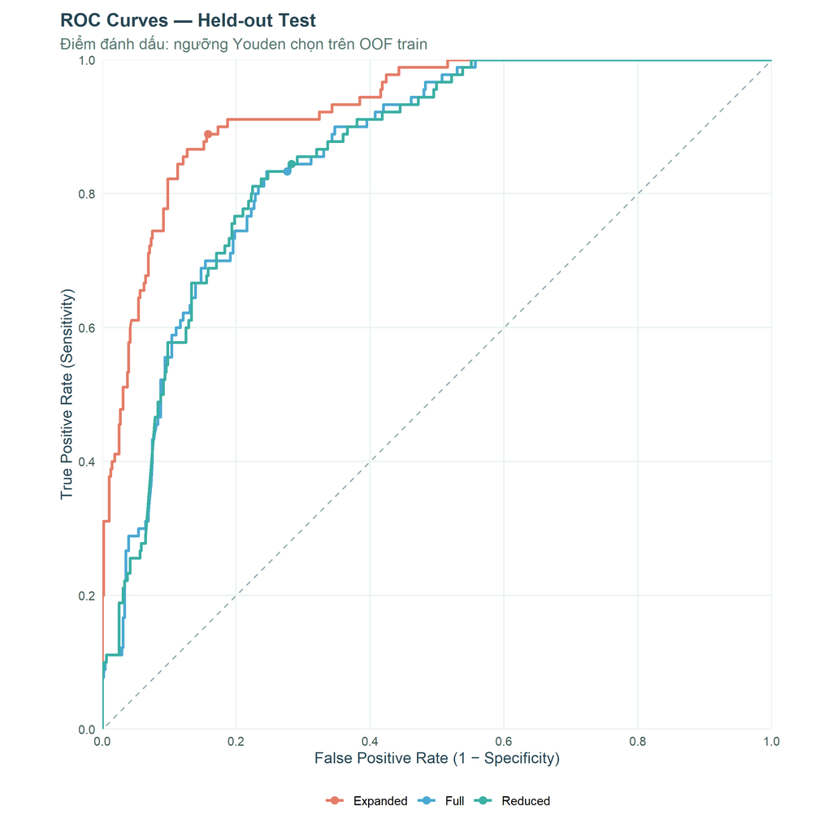

```r
roc_results <- lapply(model_test_probabilities, function(prob) {
  pROC::roc(test_model_data$churn_binary, prob,
            levels = c(0, 1), direction = "<", quiet = TRUE)
})
roc_plot_data <- purrr::imap_dfr(roc_results, function(obj, name) {
  tibble::tibble(
    FPR = 1 - obj$specificities,
    TPR = obj$sensitivities,
    Model = name
  )
})
roc_points <- purrr::imap_dfr(model_test_probabilities, function(prob, name) {
  # Ngưỡng OOF không nhất thiết trùng một mốc ROC của tập test.
  # Tính TPR/FPR trực tiếp để điểm trên biểu đồ luôn khớp confusion matrix.
  pred <- prob >= model_thresholds[[name]]
  actual <- test_model_data$churn_binary
  tibble::tibble(
    FPR = mean(pred[actual == 0]),
    TPR = mean(pred[actual == 1]),
    Model = name
  )
})
model_line_colors <- c(
  Full = chart_colors$blue,
  Reduced = chart_colors$teal,
  Expanded = chart_colors$coral
)

ggplot2::ggplot(
  roc_plot_data,
  ggplot2::aes(x = FPR, y = TPR, colour = Model)
) +
  ggplot2::geom_abline(slope = 1, intercept = 0,
                       linetype = "dashed", colour = chart_colors$gray) +
  ggplot2::geom_path(linewidth = 1.05) +
  ggplot2::geom_point(data = roc_points, size = 2.4) +
  ggplot2::scale_color_manual(values = model_line_colors) +
  ggplot2::scale_x_continuous(limits = c(0, 1), breaks = seq(0, 1, by = 0.2)) +
  ggplot2::scale_y_continuous(limits = c(0, 1), breaks = seq(0, 1, by = 0.2)) +
  ggplot2::coord_fixed(ratio = 1, expand = FALSE) +
  ggplot2::labs(
    title = "ROC Curves — Held-out Test",
    subtitle = "Điểm đánh dấu: ngưỡng Youden chọn trên OOF train",
    x = "False Positive Rate (1 − Specificity)",
    y = "True Positive Rate (Sensitivity)"
  )
```

## 5.7 Khoảng tin cậy trên test

**CI 95%** cho Sensitivity và ROC-AUC thể hiện độ bất định trên tập test hiện tại, không phản ánh biến động theo thời gian.

```r
selected_roc <- roc_results[[selected_model]]
selected_sensitivity_ci <- stats::binom.test(
  selected_result$tp, selected_result$tp + selected_result$fn,
  conf.level = 0.95
)$conf.int
selected_auc_ci <- as.numeric(pROC::ci.auc(
  selected_roc, conf.level = 0.95, method = "delong"
))

metric_ci_table <- tibble::tibble(
  Metric = c("Sensitivity", "ROC-AUC"),
  Estimate = c(selected_result$sensitivity, selected_result$auc),
  `95% CI lower` = c(selected_sensitivity_ci[1], selected_auc_ci[1]),
  `95% CI upper` = c(selected_sensitivity_ci[2], selected_auc_ci[3])
)
compact_table_with_note(metric_ci_table,
  paste0("95% Confidence Intervals on Test — ", selected_model),
  paste0("<strong>Nhận xét</strong><ul>",
    "<li>Sensitivity của mô hình được chọn: <b>",
    num(selected_result$sensitivity, 3), "</b>; 95% CI [",
    num(selected_sensitivity_ci[1], 3), "; ",
    num(selected_sensitivity_ci[2], 3), "].</li>",
    "<li>ROC-AUC: <b>", num(selected_result$auc, 3),
    "</b>; 95% CI [", num(selected_auc_ci[1], 3), "; ",
    num(selected_auc_ci[3], 3), "].</li></ul>"), digits = 3)
```

95% Confidence Intervals on Test — Expanded

| Metric | Estimate | 95% CI lower | 95% CI upper |
| --- | --- | --- | --- |
| Sensitivity | 0.889 | 0.805 | 0.945 |
| ROC-AUC | 0.927 | 0.900 | 0.954 |

**Nhận xét**

- Sensitivity của mô hình được chọn: **0,889**; 95% CI [0,805; 0,945].
- ROC-AUC: **0,927**; 95% CI [0,900; 0,954].

## 5.8 Đường cong Precision–Recall

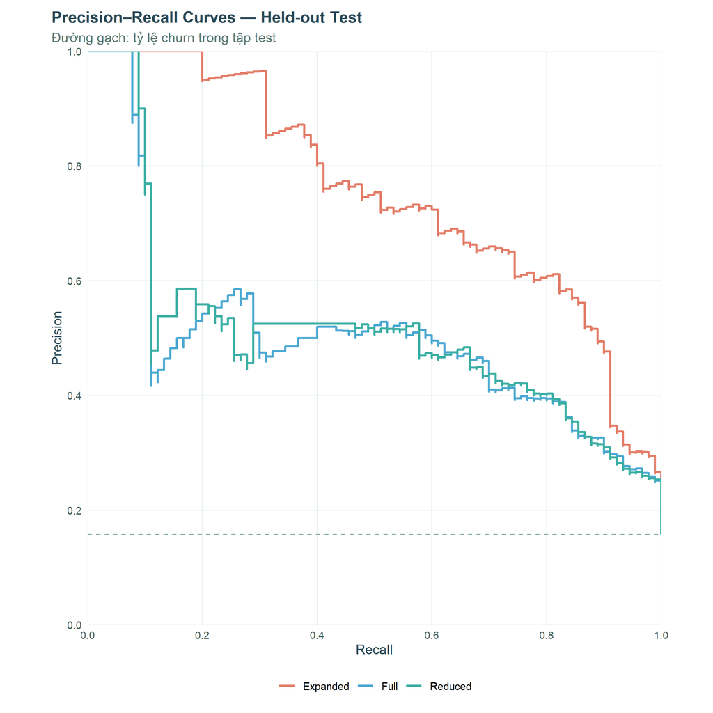

```r
make_pr_curve <- function(actual, prob, name) {
  ord <- order(prob, decreasing = TRUE)
  y <- as.integer(actual[ord] == 1)
  score <- prob[ord]
  end_idx <- which(!duplicated(score, fromLast = TRUE))
  tibble::tibble(
    Recall = c(0, cumsum(y)[end_idx] / sum(y)),
    Precision = c(1, cumsum(y)[end_idx] / end_idx),
    Model = name
  )
}
pr_plot_data <- purrr::imap_dfr(model_test_probabilities,
  ~ make_pr_curve(test_model_data$churn_binary, .x, .y))

ggplot2::ggplot(pr_plot_data,
  ggplot2::aes(Recall, Precision, colour = Model)) +
  ggplot2::geom_step(direction = "vh", linewidth = 0.9) +
  ggplot2::geom_hline(
    yintercept = mean(test_model_data$churn_binary),
    linetype = "dashed", colour = chart_colors$gray
  ) +
  ggplot2::scale_color_manual(values = model_line_colors) +
  ggplot2::scale_x_continuous(limits = c(0, 1), breaks = seq(0, 1, by = 0.2)) +
  ggplot2::scale_y_continuous(limits = c(0, 1), breaks = seq(0, 1, by = 0.2)) +
  ggplot2::coord_fixed(ratio = 1, expand = FALSE) +
  ggplot2::labs(
    title = "Precision–Recall Curves — Held-out Test",
    subtitle = "Đường gạch: tỷ lệ churn trong tập test",
    x = "Recall", y = "Precision"
  )
```

## 5.9 Hiệu chỉnh xác suất (Calibration)

Đối với **Expanded**, ta đối chiếu xác suất dự báo và tỷ lệ churn thực tế theo từng khoảng **0,1** trên OOF train và test. Không dùng test để hiệu chỉnh mô hình.

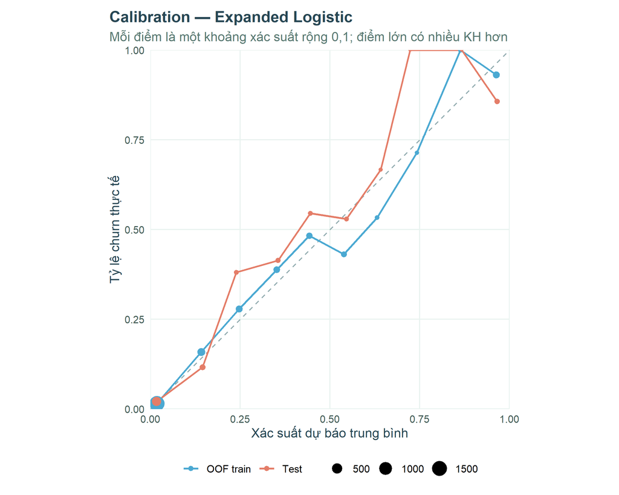

```r
calibration_bins <- function(actual, predicted, sample_name) {
  stopifnot(length(actual) == length(predicted), all(is.finite(predicted)))
  cut_id <- pmin(10L, pmax(1L, floor(predicted * 10) + 1L))
  tibble::tibble(actual = actual, predicted = predicted, bin = cut_id) |>
    dplyr::group_by(bin) |>
    dplyr::summarise(
      Customers = dplyr::n(),
      Predicted = mean(predicted),
      Observed = mean(actual), .groups = "drop") |>
    dplyr::mutate(Data = sample_name)
}
calibration_data <- dplyr::bind_rows(
  calibration_bins(oof_predictions$churn_binary,
    oof_predictions[[selected_model]], "OOF train"),
  calibration_bins(test_model_data$churn_binary,
    model_test_probabilities[[selected_model]], "Test")
)
ggplot2::ggplot(calibration_data,
  ggplot2::aes(Predicted, Observed, colour = Data)) +
  ggplot2::geom_abline(slope = 1, intercept = 0, colour = chart_colors$gray,
                       linetype = "dashed") +
  ggplot2::geom_line(ggplot2::aes(group = Data), linewidth = .85) +
  ggplot2::geom_point(ggplot2::aes(size = Customers)) +
  ggplot2::scale_colour_manual(values = c(
    "OOF train" = chart_colors$blue, "Test" = chart_colors$coral)) +
  ggplot2::coord_equal(xlim = c(0, 1), ylim = c(0, 1), expand = FALSE) +
  ggplot2::labs(title = paste0("Calibration — ", selected_model, " Logistic"),
    subtitle = "Mỗi điểm là một khoảng xác suất rộng 0,1; điểm lớn có nhiều KH hơn",
    x = "Xác suất dự báo trung bình", y = "Tỷ lệ churn thực tế") +
  ggplot2::theme(legend.position = "bottom")
```

**Brier Score test: 0,073.** Điểm càng xa đường chéo càng cho thấy xác suất dự báo lệch tỷ lệ churn thực tế; nhóm ít khách có thể dao động mạnh.

## 5.10 Ưu tiên liên hệ Top-K (Recall & Lift)

Với **Reduced** đã chọn trên train, ta xếp khách test theo nguy cơ churn và xem **top 10%, 20%, 30%** bao phủ bao nhiêu trường hợp.

```r
calculate_top_k <- function(actual, probability, fractions = c(.10, .20, .30)) {
  stopifnot(length(actual) == length(probability), all(is.finite(probability)),
            all(actual %in% c(0L, 1L)), sum(actual) > 0L)
  n <- length(actual)
  total_churn <- sum(actual)
  # Phá hòa xác suất ngẫu nhiên với seed cố định, không dùng nhãn.
  # Tránh lệch do thứ tự hàng trong CSV có thể liên quan đến churn.
  set.seed(analysis_seed)
  order_id <- order(-probability, stats::runif(n))
  purrr::map_dfr(fractions, function(frac) {
    k <- max(1L, ceiling(frac * n))
    found <- sum(actual[order_id[seq_len(k)]])
    baseline <- k * total_churn / n
    tibble::tibble(
      `Target (%)` = frac,
      `Customers contacted` = k,
      `Churn found` = found,
      `Recall@K` = found / total_churn,
      `Precision@K` = found / k,
      `Random expected` = baseline,
      `Lift@K` = (found / k) / (total_churn / n)
    )
  })
}
usage_test_prob <- model_test_probabilities[[usage_selected_model]]
top_k_result <- calculate_top_k(test_model_data$churn_binary, usage_test_prob)
top20 <- dplyr::filter(top_k_result, abs(`Target (%)` - .20) < 1e-9)
top_k_view <- top_k_result |>
  dplyr::mutate(
    `Target (%)` = scales::percent(`Target (%)`, accuracy = 1),
    `Customers contacted` = as.character(`Customers contacted`),
    `Churn found` = as.character(`Churn found`),
    `Recall@K` = scales::percent(`Recall@K`, accuracy = .1),
    `Precision@K` = scales::percent(`Precision@K`, accuracy = .1),
    `Random expected` = num(`Random expected`, 1),
    `Lift@K` = num(`Lift@K`, 2))
cat(as.character(tab(top_k_view,
  paste0("Top-K trên tập test — ", usage_selected_model, " Logistic"), digits = 1)))
```

Top-K trên tập test — Reduced Logistic

| Target (%) | Customers contacted | Churn found | Recall@K | Precision@K | Random expected | Lift@K |
| --- | --- | --- | --- | --- | --- | --- |
| 10% | 58 | 27 | 30.0% | 46.6% | 9,1 | 2,95 |
| 20% | 115 | 54 | 60.0% | 47.0% | 18,1 | 2,98 |
| 30% | 172 | 70 | 77.8% | 40.7% | 27,1 | 2,58 |

**Top 20%:** trong **115 khách** có **54 / 90 churn** (Recall **60.0%**), cao gấp **2,98 lần** kỳ vọng chọn ngẫu nhiên cùng số khách.

*K làm tròn lên; nếu bằng điểm, thứ tự được xác định bằng seed 2026. Lift@K là tỷ số giữa Precision@K và tỷ lệ churn chung.*

# 6 Hàm ý kinh doanh

## 6.1 Ưu tiên khách hàng nào?

Nếu chỉ liên hệ **20% khách có điểm cao nhất** theo **Reduced**, ta tiếp cận nhóm chứa **54 / 90 trường hợp churn** trên test. Đây là khả năng **tìm đúng người**, chưa phải hiệu quả giữ chân.

## 6.2 Các nhóm cần khảo sát nguyên nhân

- **Khiếu nại:** churn **82.61%**, so với **9.77%** ở nhóm không khiếu nại. Cần biết thêm nội dung và thời gian xử lý khiếu nại.
- **Gói cước:** Plan 1 churn **16.79%**, Plan 2 **2.62%**. Chênh lệch này chưa đủ để khuyên đổi gói.
- **Trạng thái thuê bao:** `status` có liên hệ mạnh với churn nhưng chưa rõ thời điểm ghi nhận.

## 6.3 Đo lường khi triển khai thử

Một thử nghiệm có nhóm đối chứng cần ghi lại **số khách được liên hệ, chi phí, phản hồi và tỷ lệ churn**. Từ đó mới biết liên hệ có thực sự giúp giảm churn hay không.

# 7 Kết luận và giới hạn

Sau loại trùng, tỷ lệ churn là **15.65%**. Nhóm có khiếu nại có tỷ lệ churn cao hơn **72,84 điểm phần trăm**; nhóm churn có trung vị `customer_value` thấp hơn **168,97** và trung bình `frequency_of_use` thấp hơn **47,17 lượt**.

**Expanded** dẫn đầu trên OOF train (AP **0,770**), đạt AP **0,752** trên test. Với phương án không dùng `status` (**Reduced**), chỉ cần xét **top 20%** khách điểm cao nhất đã tìm thấy **54 / 90 churn**.

**Giới hạn cần nhớ:**

- Không có **mã khách hàng** và **thời điểm ghi nhận từng hồ sơ**: chưa thể đánh giá theo thời gian hoặc xác minh dòng trùng.
- Expanded được xác định sau EDA toàn mẫu; `status` cũng chưa rõ thời điểm cập nhật. **Kết quả test của Expanded chỉ tham khảo**.
- Mô hình và ngưỡng cùng được chọn bằng OOF; kết quả CV có thể lạc quan. P-value của Reduced chưa tính đến bước chọn biến.
- **Dự báo churn không đồng nghĩa giảm churn**: cần thử nghiệm có đối chứng mới đo được hiệu quả giữ chân.

# 8 Phụ lục và khả năng tái lập

## 8.1 Dữ liệu và quyết định xử lý

- **Dữ liệu:** `Customer Churn.csv` trong `data/` hoặc `../data/`. Có 0 ô thiếu; loại 300 dòng trùng, giữ 2850 hồ sơ.
- **Bootstrap:** 5.000 mẫu theo nhóm, CI percentile 95%. **Permutation:** 10.000 lần, hai phía; điều chỉnh Holm. Gói cước có thêm kiểm định Fisher.
- **Mô hình:** chia phân tầng 80/20; 5-fold CV; AIC chọn biến trong từng fold; ngưỡng từ OOF train; seed 2026.
- **Top-K:** làm tròn K lên; phá hòa điểm bằng seed 2026 (không dùng nhãn).

## 8.2 Môi trường R và phiên bản gói

```r
package_versions <- data.frame(
  Package = required_packages,
  Version = vapply(required_packages, function(p) {
    as.character(utils::packageVersion(p))
  }, character(1)),
  check.names = FALSE
)
tab(package_versions, "Phiên bản các gói sử dụng trong bản phân tích", digits = 0)
```

Phiên bản các gói sử dụng trong bản phân tích

| Package | Version |
| --- | --- |
| tidyverse | 2.0.0 |
| janitor | 2.2.1 |
| knitr | 1.51 |
| kableExtra | 1.4.1 |
| scales | 1.4.0 |
| patchwork | 1.3.2 |
| boot | 1.3.32 |
| broom | 1.0.12 |
| car | 3.1.5 |
| pROC | 1.19.0.1 |

## 8.3 Tài liệu tham khảo

- UCI Machine Learning Repository (2020). *Iranian Churn*. DOI: 10.24432/C5JW3Z. Giấy phép dữ liệu: CC BY 4.0.